# Invasional meltdown: soil

Zhijie_Zhang

05 August, 2020

The codes for the paper **Soil-microbes-mediated invasional meltdown in plants**. This is the analyses for soil-microbe data.

**Please run [Invasional meltdown: plant] first.**

Plant data [**Invasional meltdown: plant**] showed that aliens grew better than natives on soil conditioned by aliens. On soil that was not conditioned or conditioned by natives, aliens and natives were similar.

Here I analyzed soil samples from the soil-conditioning phase (4 alien + 6 native species + non-conditioned soil, sterilized or not before training. I have 115 samples for bacterial communities and 111 samples for fungal communities.

Note that, when testing the relationship (beta, $\beta$ in Fig. 1) between soil-legacy effect and soil-communities (alpha, $\alpha$ in Fig. 1), I only used non-sterilized soil. This is because the test plants were only grown on the non-sterilized soil.

**Findings**:

1. Alien and native conditioned the soil in different ways, reflected by compositions of baterial and fungal communities (section 3).
2. Aliens and aliens shared a few fungal endophytes. Alien and natives shared some endophytes And native and natives shared many endophytes (section 4.1).
3. Alpha divesrity of soil microbes and relative abundance of fungal pathogens, overally, did not differ between aliens and natives. (section 5).
4. Soil-legacy effect was not significantly explained by diversity/abundance of soil microbes (section 6.2), but was significantly explained by the similarity in fungal endophyte communities between plant species (section 6.1.1).

```r
knitr::opts_chunk$set(warning=F,message = F)
dir.create('table',showWarnings = F)
dir.create('fig',showWarnings = F)
```

```r
source('01functions.R')
load('04phyloseq_16s_its.RData') # phyloseq, cleaned
load('legacy_beta.RData')      # soil legacy effect, from plant data.
```

```r
library(stringr)
library(corrplot)
library(nlme)
library(vegan)
library(phyloseq)
library(themetagenomics)
require(reshape2)
library(RColorBrewer)
library(tidyverse)
library(gridExtra)
library(phytools)
library(knitr)
library(shape)
library(pBrackets)
library(scales)
library(MuMIn)
```

```r
col_fig <- c('#FFA733', '#971997')

theme <- theme_bw() +
  theme(panel.background = element_blank(), panel.grid.major = element_blank(),
        panel.grid.minor = element_blank(),
        strip.background = element_blank(),
        legend.key = element_rect(colour = NA, fill = NA),
        legend.background = element_blank(),
        legend.title = element_blank(),
        axis.text.x = element_text(size = 6, colour = 'black'),
        axis.text.y = element_text(size = 6, colour = 'black'),
        axis.title  = element_text(size = 6, colour = 'black'),
        title = element_text(size = 7),
        plot.title   = element_text(size = 7, hjust = 0.5),
        strip.text.x = element_text(size = 6),
        plot.tag   = element_text(size = 7, face = 'bold'),
        legend.position = "none",
        plot.margin = margin(t = 0.5, r = 0.1, b = 0.5, l = 0.1, unit = "cm"))
```

# 1 data preparation

check reads and decide the rarefy depth

```r
print('samples with the lowest reads')
```

```
## [1] "samples with the lowest reads"
```

```r
(sort(sample_sums(phyloseq_16s_raw)))[1:5]
```

```
## FDMP19H001153-1a_L1_SV1626  FDMP19H001152-1a_L1_SV428
##                      22465                      30376
## FDMP19H001154-1a_L1_SV1754  FDMP19H001152-1a_L1_SV652
##                      33161                      33338
##  FDMP19H001152-1a_L1_SV936
##                      33646
```

```r
(sort(sample_sums(phyloseq_its_raw)))[1:5]
```

```
## FDMP19H001240-1a_L1_ITS1770 FDMP19H001240-1a_L1_ITS1767
##                        2211                        5022
## FDMP19H001243-1a_L1_ITS1091  FDMP19H001243-1a_L1_ITS957
##                        9588                       11612
## FDMP19H001239-1a_L1_ITS1751
##                       13265
```

rarefy 16s and its to same reads, 30000 for 16s, and 9500 for its  
one samples (1626) were removed for 16s  
two samples (1770 and 1767) were removed for its.

get otu/tax/sample tables

```r
# 16s
otu_table_16s <- as.data.frame(phyloseq_16s@otu_table@.Data)
tax_table_16s <- as.data.frame(phyloseq_16s@tax_table@.Data)
sam_table_16s <- as(sample_data(phyloseq_16s), "data.frame") %>%
  # -------------- rename some variables to make them consistent with the plant data ---------------#
  mutate(status = recode(status, 'a' = 'alien', 'n' = 'native', 'ck' = 'non-conditioned')) %>%
  mutate(species = recode(species, 'Solidago' = "Solidago_gigantea",  'Leontodon' = "Leontodon_autumnalis",
                          'Salvia_ver' ="Salvia_verticillata", 'Salvia' = "Salvia_pratensis",
                          'Plantago' = "Plantago_media", 'Onobrychis' =  "Onobrychis_viciifolia",
                          'Lotus' = "Lotus_corniculatus", 'Lolium' = "Lolium_multiflorum",
                          'Cynosurus' = "Cynosurus_cristatus", 'Dactylis' = "Dactylis_glomerata",
                          'ck' = 'non-conditioned')) %>%
  arrange(match(sample_id, rownames(otu_table_16s)))

# its
otu_table_its <- as.data.frame(phyloseq_its@otu_table@.Data)
tax_table_its <- as.data.frame(phyloseq_its@tax_table@.Data)
sam_table_its <- as(sample_data(phyloseq_its), "data.frame") %>%
  mutate(status = recode(status, 'a' = 'alien', 'n' = 'native', 'ck' = 'non-conditioned')) %>%
  mutate(species = recode(species,'Solidago' = "Solidago_gigantea",
                          'Leontodon' = "Leontodon_autumnalis",
                          'Salvia_ver' ="Salvia_verticillata",
                          'Salvia' = "Salvia_pratensis",
                          'Plantago' = "Plantago_media",
                          'Onobrychis' =  "Onobrychis_viciifolia",
                          'Lotus' = "Lotus_corniculatus",
                          'Lolium' = "Lolium_multiflorum",
                          'Cynosurus' = "Cynosurus_cristatus",
                          'Dactylis' = "Dactylis_glomerata",
                          'ck' = 'non-conditioned')) %>%
  arrange(match(sample_id, rownames(otu_table_its)))
info_family<- data.frame(species = sort(unique(sam_table_16s$species)),
                         family = c('non-conditioned','Poaceae','Poaceae','Compositae','Poaceae',
                                    'Leguminosae','Leguminosae','Plantaginaceae','Lamiaceae','Lamiaceae','Compositae')) #informations

sam_table_16s <- sam_table_16s%>%
  left_join(info_family) %>%
  mutate(T1_empty = ifelse(status == 'non-conditioned', -2/3, 1/3),
         T2_alien_native = ifelse(status == 'non-conditioned', 0,
                                  ifelse(status == 'alien', 0.5, -0.5))) %>%
  mutate(trans_date_c=ifelse(fix %in% c(1360:1400), 28,# add transplanting date, salvia
                             ifelse(fix %in% c(1492:1568), 33, # solidago gigantea
                                    ifelse(species == "Salvia_verticillata", 15,
                                           ifelse(species == "Solidago_gigantea", 20,
                                                  ifelse(species =='Plantago_media', 2,0))))))
sam_table_its <- sam_table_its %>%
  left_join(info_family) %>%
  # set contrast for the three levels (non-conditioned, alien, native)
  mutate(T1_empty = ifelse(status == 'non-conditioned', -2/3, 1/3),
         T2_alien_native = ifelse(status == 'non-conditioned', 0,
                                  ifelse(status == 'alien', 0.5, -0.5))) %>%
  # ------------add transplanting date-------------#
  mutate(trans_date_c = ifelse(fix %in% c(1360:1400), 28, # salvia
                               ifelse(fix %in% c(1492:1568), 33,# solidago
                                      ifelse(species == "Salvia_verticillata", 15,
                                             ifelse(species == "Solidago_gigantea", 20,
                                                    ifelse(species == 'Plantago_media', 2, 0))))))

#change order of status, make the plotting easier
sam_table_its$status <- factor(sam_table_its$status, levels = c('non-conditioned', 'alien', 'native'))
sam_table_16s$status <- factor(sam_table_16s$status, levels = c('non-conditioned', 'alien', 'native'))
```

# 2 assign its to FUNGuild

get the names of the taxa, and then match functional groups from the FUNGuild.  
accessed on 2019-10-30

```r
# its_otu<- as.data.frame(phyloseq_its_raw@otu_table)
# transposed_otu_table <- as.data.frame(t(its_otu))# Table transposition
# transposed_otu_table$OTU_ID <- rownames(transposed_otu_table)
# transposed_otu_table<-remove_rownames(transposed_otu_table)
#
#
# its_tax<-as.data.frame(phyloseq_its_raw@tax_table@.Data)
# tax <- data.frame(taxonomy=paste(its_tax$Kingdom,
#                                  its_tax$Phylum,
#                                  its_tax$Class,
#                                  its_tax$Order,
#                                  its_tax$Family,
#                                  its_tax$Genus,
#                                  its_tax$Species, sep=";"),its_tax[,0])
# tax$OTU_ID <- rownames(tax)
# tax<-remove_rownames(tax)
#
# df_its_tax<-transposed_otu_table%>%
#   left_join(tax)
#
# write.table(df_its_tax, file = paste(path,'dfr_funguild.txt', sep = ''),
#             quote=FALSE, sep = " ", dec = ".",
#             row.names = FALSE, col.names = TRUE)
# rm(df_its_tax,tax,its_tax,its_otu,transposed_otu_table)
# Run funguil_assigment on http://www.stbates.org/guilds/app.php. Register the file in csv df_funguilds.guilds.txt

# Formatting its tables for complete statistical analysis (samples in rows and variables in columns)
```

# 3 soil-communitiy composition

**This section aims to test whether plant affected the soil communities, and whether the effect depends on the origin (native vs alien).**

the contrasts:  
T1_empthy: ck vs mean of native and alien  
T2 alien_native: alien vs native

data prep

```r
# filter data
sam_table_16s_nonster <- sam_table_16s %>%
  filter(ster.not == 'nonster') %>% droplevels()

sam_table_16s_ster <- sam_table_16s %>%
  filter(ster.not == 'ster') %>% droplevels()

sam_table_its_nonster <- sam_table_its %>%
  filter(ster.not == 'nonster') %>% droplevels()

sam_table_its_ster   <- sam_table_its %>%
  filter(ster.not=='ster') %>% droplevels()


# extract otu
otu_table_16s_nonster <- otu_table_16s[as.character(sam_table_16s_nonster$sample_id),]
otu_table_16s_ster    <- otu_table_16s[as.character(sam_table_16s_ster$sample_id),]
otu_table_its_nonster <- otu_table_its[as.character(sam_table_its_nonster$sample_id),]
otu_table_its_ster    <- otu_table_its[as.character(sam_table_its_ster$sample_id),]
```

assign functional groups

```r
its_func <- read.csv('05dfr_funguild_guilds.csv')
# clean the functional groups
its_func <- its_func %>%
  mutate(pathogen = ifelse(grepl('plant patho|plant parasite', Guild, ignore.case = T) &
                             !(grepl('polen',Guild,ignore.case = T)),'pathogen',0), # some are pollen (polen is a typo in the funguild?)
         AMF      = ifelse(grepl('Arbuscular Mycorrhizal', Guild, ignore.case = T), 'AMF', 0),
         endo     = ifelse(grepl('endophyt',               Guild, ignore.case = T), 'endo',0),
         assigned = ifelse(Guild =='-', 0, 'assigned')) %>%
  mutate(endo_path    = ifelse(endo == 'endo' & pathogen == 'pathogen', 'endo_path', 0),    # pathogenic endophytes
         endo_no_path = ifelse(endo == 'endo' & pathogen != 'pathogen', 'endo_no_path', 0), # non-pathogenic endophytes
         )
```

```r
its_func          <- its_func %>% filter(OTU_ID %in% as.character(colnames(otu_table_its)))
its_func_nonster  <- its_func %>% filter(OTU_ID %in% as.character(colnames(otu_table_its_nonster)))
its_func_ster     <- its_func %>% filter(OTU_ID %in% as.character(colnames(otu_table_its_ster)))
```

```r
# otu table, subset
# -------------not sterilized----------------#
otu_table_its_nonster_pathogen <-
  otu_table_its_nonster[,as.character(its_func_nonster$OTU_ID[its_func_nonster[,'pathogen'] == 'pathogen'])] # pathogen
otu_table_its_nonster_endo <-
  otu_table_its_nonster[,as.character(its_func_nonster$OTU_ID[its_func_nonster[,'endo'] == 'endo'])]            # endophytes

# two subsets of endophytes
otu_table_its_nonster_endo_path <-
  otu_table_its_nonster[,as.character(its_func_nonster$OTU_ID[its_func_nonster[,'endo_path'] == 'endo_path'])]
otu_table_its_nonster_endo_no_path <-
  otu_table_its_nonster[,as.character(its_func_nonster$OTU_ID[its_func_nonster[,'endo_no_path'] == 'endo_no_path'])]

otu_table_its_nonster_amf  <-
  otu_table_its_nonster[,as.character(its_func_nonster$OTU_ID[its_func_nonster[,'AMF'] == 'AMF'])]               # AMF

# ---------------sterilized soil ----------------#
otu_table_its_ster_pathogen <- otu_table_its_ster[,as.character(its_func_ster$OTU_ID[its_func_ster[,'pathogen'] == 'pathogen'])]
otu_table_its_ster_endo     <- otu_table_its_ster[,as.character(its_func_ster$OTU_ID[its_func_ster[,'endo'] == 'endo'])]
otu_table_its_ster_amf      <- otu_table_its_ster[,as.character(its_func_ster$OTU_ID[its_func_ster[,'AMF'] == 'AMF'])]
```

NDMS: 16s (bacteria), its (fungi) and fungal pathogens.  
Bray-Curtis dissimilarity was calculated between samples.

```r
beta_all <- lapply(list(otu_table_16s_nonster,      otu_table_16s_ster, # bacteria
                    otu_table_its_nonster,          otu_table_its_ster, # fungi
                    otu_table_its_nonster_pathogen, otu_table_its_ster_pathogen), # fungal pathogens
               function(otu) {metaMDS(otu, trymax = 10000, autotransform = FALSE, trace = FALSE, k=2)})
```

```r
# colors for the NDMS figures
col_table <- sam_table_16s_nonster %>%
  dplyr::select(status,species) %>%
  distinct() %>%
  arrange(status) %>%
  mutate(pch = 16) # order according to status

col_table$col<-c('black',
                 colorRampPalette(c('orangered', 'yellow'))(5)[1:4],
                 c(brewer.pal(12, 'Paired')[c(1:2)],  'royalblue4',
                   brewer.pal(12, 'Paired')[c(9:10)], 'violetred2')
                 )

# info
sam_table_16s_nonster <- sam_table_16s_nonster %>% left_join(col_table)
sam_table_16s_ster    <- sam_table_16s_ster    %>% left_join(col_table)
sam_table_its_nonster <- sam_table_its_nonster %>% left_join(col_table)
sam_table_its_ster    <- sam_table_its_ster    %>% left_join(col_table)
```

all models  
Note that as adonis is tested with randomization, the results in the report will differ sightly with that in the manuscript.

```r
# -------------non sterilized----------------#
t_struct_16s <- adonis(otu_table_16s_nonster~ T1_empty + T2_alien_native + family + species + trans_date_c,
                       data = sam_table_16s_nonster)
t_struct_its <- adonis(otu_table_its_nonster ~ T1_empty + T2_alien_native + family + species + trans_date_c,
                       data = sam_table_its_nonster)
t_struct_its_nonster_pathogen <- adonis(otu_table_its_nonster_pathogen ~ T1_empty + T2_alien_native +
                                          family + species + trans_date_c,
                                        data = sam_table_its_nonster)

# -------------sterilized----------------#
t_struct_16s_ster <- adonis(otu_table_16s_ster~ T1_empty + T2_alien_native + family + species + trans_date_c,
       data = sam_table_16s_ster)

t_struct_its_ster <- adonis(otu_table_its_ster ~ T1_empty + T2_alien_native + family + species + trans_date_c,
                            data = sam_table_its_ster)
t_struct_its_ster_pathogen    <- adonis(otu_table_its_ster_pathogen ~ T1_empty + T2_alien_native +
                                          family + species + trans_date_c,
                                        data = sam_table_its_ster)
#-------------------------#
t_struct_16s <- t_struct_16s$aov.tab %>% as.data.frame()
t_struct_its <- t_struct_its$aov.tab %>% as.data.frame()
t_struct_its_nonster_pathogen <- t_struct_its_nonster_pathogen$aov.tab %>% as.data.frame()

t_struct_16s_ster <- t_struct_16s_ster$aov.tab %>% as.data.frame()
t_struct_its_ster <- t_struct_its_ster$aov.tab %>% as.data.frame()
t_struct_its_ster_pathogen <- t_struct_its_ster_pathogen$aov.tab %>% as.data.frame()
```

## 3.1 non-sterilized soil

### 3.1.1 16s (bacteria)

```r
t_struct_16s %>% kable(digits = 3)
```

|  | Df | SumsOfSqs | MeanSqs | F.Model | R2 | Pr(>F) |
| --- | --- | --- | --- | --- | --- | --- |
| T1_empty | 1 | 0.174 | 0.174 | 1.711 | 0.022 | 0.005 |
| T2_alien_native | 1 | 0.249 | 0.249 | 2.442 | 0.032 | 0.001 |
| family | 4 | 1.137 | 0.284 | 2.790 | 0.146 | 0.001 |
| species | 4 | 0.686 | 0.172 | 1.684 | 0.088 | 0.001 |
| trans_date_c | 1 | 0.125 | 0.125 | 1.226 | 0.016 | 0.105 |
| Residuals | 53 | 5.399 | 0.102 | NA | 0.695 | NA |
| Total | 64 | 7.770 | NA | NA | 1.000 | NA |

### 3.1.2 its (all fungi)

```r
t_struct_its %>% kable(digits = 3)
```

|  | Df | SumsOfSqs | MeanSqs | F.Model | R2 | Pr(>F) |
| --- | --- | --- | --- | --- | --- | --- |
| T1_empty | 1 | 0.355 | 0.355 | 1.493 | 0.023 | 0.100 |
| T2_alien_native | 1 | 0.434 | 0.434 | 1.826 | 0.028 | 0.027 |
| family | 4 | 1.295 | 0.324 | 1.361 | 0.082 | 0.034 |
| species | 4 | 1.443 | 0.361 | 1.517 | 0.092 | 0.010 |
| trans_date_c | 1 | 0.273 | 0.273 | 1.148 | 0.017 | 0.240 |
| Residuals | 50 | 11.894 | 0.238 | NA | 0.758 | NA |
| Total | 61 | 15.694 | NA | NA | 1.000 | NA |

### 3.1.3 fungal pathogen

```r
t_struct_its_nonster_pathogen %>% kable(digits = 3)
```

|  | Df | SumsOfSqs | MeanSqs | F.Model | R2 | Pr(>F) |
| --- | --- | --- | --- | --- | --- | --- |
| T1_empty | 1 | 0.320 | 0.320 | 1.387 | 0.021 | 0.139 |
| T2_alien_native | 1 | 0.460 | 0.460 | 1.995 | 0.031 | 0.013 |
| family | 4 | 1.132 | 0.283 | 1.228 | 0.076 | 0.090 |
| species | 4 | 1.360 | 0.340 | 1.475 | 0.091 | 0.010 |
| trans_date_c | 1 | 0.196 | 0.196 | 0.851 | 0.013 | 0.654 |
| Residuals | 50 | 11.524 | 0.230 | NA | 0.769 | NA |
| Total | 61 | 14.992 | NA | NA | 1.000 | NA |

## 3.2 sterilized

### 3.2.1 16s (bacteria)

```r
t_struct_16s_ster %>% kable(digits = 3)
```

|  | Df | SumsOfSqs | MeanSqs | F.Model | R2 | Pr(>F) |
| --- | --- | --- | --- | --- | --- | --- |
| T1_empty | 1 | 0.876 | 0.876 | 8.087 | 0.124 | 0.001 |
| T2_alien_native | 1 | 0.249 | 0.249 | 2.298 | 0.035 | 0.006 |
| family | 4 | 1.172 | 0.293 | 2.705 | 0.165 | 0.001 |
| species | 4 | 0.673 | 0.168 | 1.553 | 0.095 | 0.003 |
| Residuals | 38 | 4.117 | 0.108 | NA | 0.581 | NA |
| Total | 48 | 7.088 | NA | NA | 1.000 | NA |

### 3.2.2 its (all fungi)

```r
t_struct_its_ster %>% kable(digits = 3)
```

|  | Df | SumsOfSqs | MeanSqs | F.Model | R2 | Pr(>F) |
| --- | --- | --- | --- | --- | --- | --- |
| T1_empty | 1 | 0.332 | 0.332 | 1.198 | 0.024 | 0.246 |
| T2_alien_native | 1 | 0.416 | 0.416 | 1.498 | 0.031 | 0.108 |
| family | 4 | 1.501 | 0.375 | 1.352 | 0.111 | 0.072 |
| species | 4 | 1.330 | 0.332 | 1.198 | 0.098 | 0.193 |
| Residuals | 36 | 9.991 | 0.278 | NA | 0.736 | NA |
| Total | 46 | 13.570 | NA | NA | 1.000 | NA |

### 3.2.3 fungal pathogens

```r
t_struct_its_ster_pathogen %>% kable(digits = 3)
```

|  | Df | SumsOfSqs | MeanSqs | F.Model | R2 | Pr(>F) |
| --- | --- | --- | --- | --- | --- | --- |
| T1_empty | 1 | 0.657 | 0.657 | 2.379 | 0.047 | 0.025 |
| T2_alien_native | 1 | 0.137 | 0.137 | 0.497 | 0.010 | 0.899 |
| family | 4 | 1.780 | 0.445 | 1.611 | 0.128 | 0.034 |
| species | 4 | 1.438 | 0.360 | 1.302 | 0.103 | 0.132 |
| Residuals | 36 | 9.947 | 0.276 | NA | 0.713 | NA |
| Total | 46 | 13.960 | NA | NA | 1.000 | NA |

## 3.3 figures

### 3.3.1 bacteria and fungi (Extended Fig. 2)

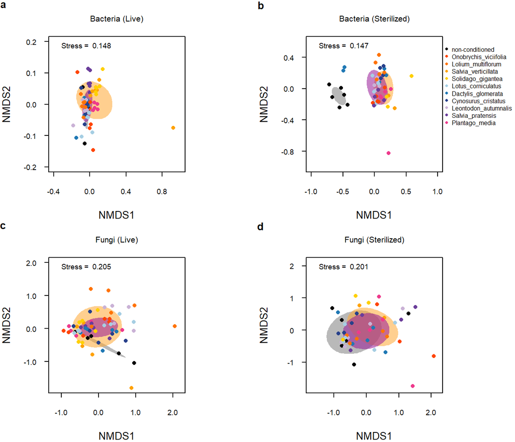

```r
# pdf('./fig/struct.pdf', height = 6, width = 18/2.54, useDingbats=FALSE)
par(mfrow = c(2,2), xpd = T)

beta_plot(beta_all[[1]],sam_table_16s_nonster,ylim = c(-0.2,0.2),xlim = c(-0.4,1),
          yaxt = c(-0.2, -0.1, 0, 0.1, 0.2), xaxt = c(-0.4,0,0.4,0.8))
title('Bacteria (Live)', cex.main = 0.8, font.main = 1)


beta_plot(beta_all[[2]], sam_table_16s_ster,xlim = c(-1,1),ylim = c(-1,0.6),
          yaxt = c(-0.8,-0.4,0,0.4), xaxt = c(-1,-0.5,0, 0.5, 1), tag = 'b')
title('Bacteria (Sterilized)', cex.main = 0.8, font.main = 1)
legend(1.05,0.6, col_table$species, col = col_table$col, pch = 16,bty = 'n', cex = 0.6)

beta_plot(beta_all[[3]], sam_table_its_nonster,xlim = c(-1.2,2.2),ylim = c(-1.8,2),
          yaxt = c(-1, 0, 1, 2), tag = 'c')
title('Fungi (Live)', cex.main = 0.8, font.main = 1)

beta_plot(beta_all[[4]], sam_table_its_ster,xlim = c(-1.7,2.2),ylim = c(-1.8,2.1),
          yaxt = NULL, xaxt = c(-1, 0, 1, 2), tag = 'd')
title('Fungi (Sterilized)', cex.main = 0.8, font.main = 1)
```

```r
# dev.off()
```

### 3.3.2 fungal pathogens (Supplementary Fig. 3)

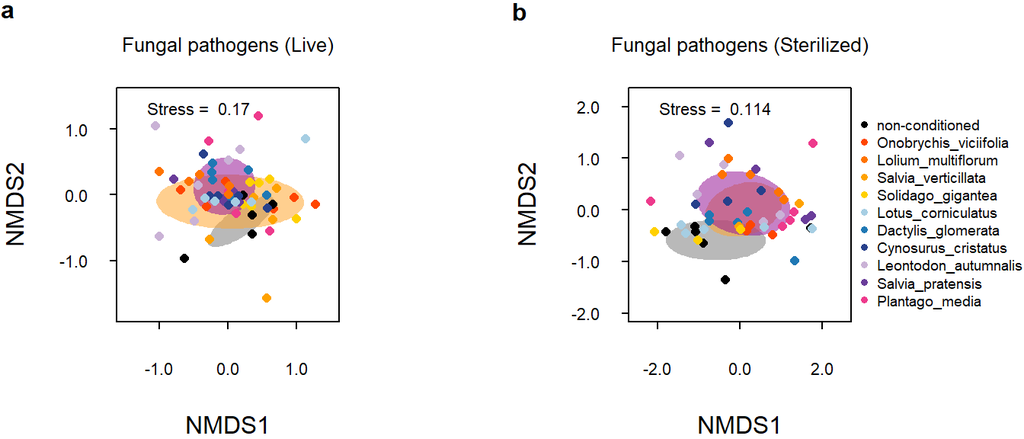

```r
# pdf('./fig/struct_fungi.pdf', height = 3, width = 18/2.54)
par(mfrow = c(1,2), xpd = T)
beta_plot(beta_all[[5]],sam_table_its_nonster,
          ylim = c(-1.8,1.5), xlim = c(-1.5,1.5),
          yaxt = c(-1, 0, 1), xaxt = c(-1, 0, 1))
title('Fungal pathogens (Live)', cex.main = 0.8, font.main = 1)

beta_plot(beta_all[[6]],sam_table_its_ster,
          ylim = c(-2,2.2), xlim = c(-2.5,2.5),
          yaxt = c(-2, -1, 0, 1, 2), xaxt = c(-2, 0, 2), tag = 'b')
title('Fungal pathogens (Sterilized)', cex.main = 0.8, font.main = 1)
legend(2.7,2, col_table$species, col = col_table$col, pch = 16, bty = 'n', cex = 0.6)
```

```r
# dev.off()
```

export tables

```r
# write.csv(rbind(t_struct_16s,t_struct_16s_ster,
#                 t_struct_its, t_struct_its_ster),
#           './table/t_structure.csv')
```

```r
# write.csv(rbind(t_struct_its_nonster_pathogen, t_struct_its_ster_pathogen), './table/t_structure_pathogen.csv')
```

# 4 soil communities dissimilarity between plants

**This section aims to test whether similarity of soil communities (Bray-Curtis dissimilarities, or beta diversity) depends on the combination of species.** (five combinations: alien on its own [intra_a], native on its own [intra_n], aliens with aliens[a a], aliens with natives[n a], and natives with natives[n n])

I first calculated the beta diversity between every two samples.  
Then, basing on them, I calculated the mean beta diversity between every two-species combinations.  
Last, I tested whether the five combinations (intra_a, intra_n, aa, na, nn) matters.

```r
info_16s <- sam_table_16s %>%
  dplyr::select(species, status, ster.not, sample_id, trans_date_c) %>%
  arrange(ster.not, status, species, sample_id) %>%
  droplevels()

info_its <- sam_table_its %>%
  dplyr::select(species, status, ster.not, sample_id, trans_date_c)
```

**aa** means alien with alien, **na** means native with alien, and **nn** means native with native.

```r
beta_mat_sp_16s_nonster <- beta_by_sp(otu_table_16s_nonster, info_16s) # matrix for 16s nonsterilized
beta_mat_sp_its_nonster <- beta_by_sp(otu_table_its_nonster, info_its) # its, nonsterilized
beta_mat_sp_16s_ster    <- beta_by_sp(otu_table_16s_ster,    info_16s) # 16s, sterilized
beta_mat_sp_its_ster    <- beta_by_sp(otu_table_its_ster,    info_its) # its, sterilized
```

```r
beta_mat_sp_its_nonster_pathogen <- beta_by_sp(otu_table_its_nonster_pathogen, info_its)
beta_mat_sp_its_nonster_endo     <- beta_by_sp(otu_table_its_nonster_endo,     info_its)
beta_mat_sp_its_nonster_endo_path    <- beta_by_sp(otu_table_its_nonster_endo_path,   info_its)
beta_mat_sp_its_nonster_endo_no_path <- beta_by_sp(otu_table_its_nonster_endo_no_path,info_its)

beta_mat_sp_its_ster_pathogen <- beta_by_sp(otu_table_its_ster_pathogen,info_its)
beta_mat_sp_its_ster_endo     <- beta_by_sp(otu_table_its_ster_endo,    info_its)
```

## 4.1 non-sterilized soil

### 4.1.1 16s (bacteria)

```r
u<-gl(1,1,length(beta_mat_sp_16s_nonster$mean_beta))
model <- lme(logit(mean_beta)~ aa_vs_na + na_vs_nn + intra_vs_inter + intra_a_vs_n,
             random=list(u=pdBlocked(list(
              pdIdent(form=~sp1-1),
              pdIdent(form=~sp2-1),
              pdIdent(form=~family1-1),
              pdIdent(form=~family2-1)
              ))),
             control = lmeControl(msMaxIter = 10000),
             weights = varIdent(form = ~1|combi_status),
             data = beta_mat_sp_16s_nonster, method = 'ML')
```

```r
t_beta_16s <- merge_fix_rand(drop1(model, test = 'Chisq')[-1,], model)
t_beta_16s %>% kable
```

|  | X2 | P |
| --- | --- | --- |
| aa_vs_na | 0.706 | 0.401 |
| na_vs_nn | 2.687 | 0.101 |
| intra_vs_inter | 4.307 | 0.038* |
| intra_a_vs_n | 0.080 | 0.777 |
| Random effects | SD |  |
| sp1 | 0.079 |  |
| sp2 | 0.006 |  |
| family1 | 0.063 |  |
| family2 | 0.042 |  |
| Residual | 0.080 |  |

### 4.1.2 its (fungi)

```r
print('all fungi')
```

```
## [1] "all fungi"
```

```r
u <- gl(1,1,length(beta_mat_sp_its_nonster$mean_beta))
model <- update(model, weights = varIdent(form = ~1|combi_status), data = beta_mat_sp_its_nonster)
t_beta_its <- merge_fix_rand(drop1(model, test = 'Chisq')[-1,], model)
t_beta_its %>% kable
```

|  | X2 | P |
| --- | --- | --- |
| aa_vs_na | 4.001 | 0.045* |
| na_vs_nn | 3.123 | 0.077† |
| intra_vs_inter | 1.038 | 0.308 |
| intra_a_vs_n | 1.122 | 0.289 |
| Random effects | SD |  |
| sp1 | 0.137 |  |
| sp2 | 0.207 |  |
| family1 | 0.000 |  |
| family2 | 0.071 |  |
| Residual | 0.039 |  |

```r
print('pathogen')
```

```
## [1] "pathogen"
```

```r
u<-gl(1,1,length(beta_mat_sp_its_nonster_pathogen$mean_beta))
model <- update(model, weights = varIdent(form = ~1|combi_status),
                data = beta_mat_sp_its_nonster_pathogen,
                control = lmeControl(opt = 'optim'))

t_beta_its_path <- merge_fix_rand(drop1(model, test = 'Chisq')[-1,], model)
t_beta_its_path %>% kable
```

|  | X2 | P |
| --- | --- | --- |
| aa_vs_na | 0.831 | 0.362 |
| na_vs_nn | 3.099 | 0.078† |
| intra_vs_inter | 2.513 | 0.113 |
| intra_a_vs_n | 1.705 | 0.192 |
| Random effects | SD |  |
| sp1 | 0.160 |  |
| sp2 | 0.195 |  |
| family1 | 0.000 |  |
| family2 | 0.000 |  |
| Residual | 0.130 |  |

```r
print('all endophytes')
```

```
## [1] "all endophytes"
```

```r
u<-gl(1,1,length(beta_mat_sp_its_nonster_endo$mean_beta))
model <- update(model, data = beta_mat_sp_its_nonster_endo, method = 'ML')
t_beta_its_endo <- merge_fix_rand(drop1(model, test = 'Chisq')[-1,], model)
t_beta_its_endo %>% kable
```

|  | X2 | P |
| --- | --- | --- |
| aa_vs_na | 12.108 | 0.001* |
| na_vs_nn | 10.527 | 0.001* |
| intra_vs_inter | 0.150 | 0.698 |
| intra_a_vs_n | 16.292 | 0.000* |
| Random effects | SD |  |
| sp1 | 0.104 |  |
| sp2 | 0.058 |  |
| family1 | 0.000 |  |
| family2 | 0.022 |  |
| Residual | 0.120 |  |

endophty into two subsets

```r
print('pathogenic endophytes')
```

```
## [1] "pathogenic endophytes"
```

```r
model <- update(model, data = beta_mat_sp_its_nonster_endo_path, control = NULL)
t_beta_its_endo_path <- merge_fix_rand(drop1(model, test = 'Chisq')[-1,], model)
t_beta_its_endo_path %>% kable
```

|  | X2 | P |
| --- | --- | --- |
| aa_vs_na | 3.611 | 0.057† |
| na_vs_nn | 4.812 | 0.028* |
| intra_vs_inter | 1.993 | 0.158 |
| intra_a_vs_n | 4.159 | 0.041* |
| Random effects | SD |  |
| sp1 | 0.154 |  |
| sp2 | 0.175 |  |
| family1 | 0.000 |  |
| family2 | 0.000 |  |
| Residual | 0.084 |  |

```r
print('non-pathogenic endophytes')
```

```
## [1] "non-pathogenic endophytes"
```

```r
model <- update(model, data = beta_mat_sp_its_nonster_endo_no_path, control = lmeControl(msMaxIter = 10000))
t_beta_its_endo_no_path <- merge_fix_rand(drop1(model, test = 'Chisq')[-1,], model)
t_beta_its_endo_no_path %>% kable
```

|  | X2 | P |
| --- | --- | --- |
| aa_vs_na | 7.863 | 0.005* |
| na_vs_nn | 2.324 | 0.127 |
| intra_vs_inter | 2.859 | 0.091† |
| intra_a_vs_n | 10.510 | 0.001* |
| Random effects | SD |  |
| sp1 | 0.118 |  |
| sp2 | 0.100 |  |
| family1 | 0.030 |  |
| family2 | 0.000 |  |
| Residual | 0.162 |  |

## 4.2 sterilized soil

### 4.2.1 16s (bacteria)

```r
u<-gl(1,1,length(beta_mat_sp_16s_ster$mean_beta))
model <- update(model, data = beta_mat_sp_16s_ster, weights = NULL)
t_beta_16s_ster <- merge_fix_rand(drop1(model, test = 'Chisq')[-1,], model)  # table
t_beta_16s_ster %>% kable
```

|  | X2 | P |
| --- | --- | --- |
| aa_vs_na | 0.002 | 0.962 |
| na_vs_nn | 0.257 | 0.612 |
| intra_vs_inter | 16.693 | 0.000* |
| intra_a_vs_n | 0.559 | 0.454 |
| Random effects | SD |  |
| sp1 | 0.148 |  |
| sp2 | 0.087 |  |
| family1 | 0.085 |  |
| family2 | 0.095 |  |
| Residual | 0.060 |  |

### 4.2.2 its (fungi)

```r
print('all fungi')
```

```
## [1] "all fungi"
```

```r
u<-gl(1,1,length(beta_mat_sp_its_ster$mean_beta))
model<-update(model,
              control = NULL, weights = NULL,
              data = beta_mat_sp_its_ster)
t_beta_its_ster <- merge_fix_rand(drop1(model, test = 'Chisq')[-1,], model)
t_beta_its_ster %>% kable
```

|  | X2 | P |
| --- | --- | --- |
| aa_vs_na | 0.090 | 0.764 |
| na_vs_nn | 0.673 | 0.412 |
| intra_vs_inter | 0.069 | 0.793 |
| intra_a_vs_n | 0.085 | 0.771 |
| Random effects | SD |  |
| sp1 | 0.400 |  |
| sp2 | 0.175 |  |
| family1 | 0.196 |  |
| family2 | 0.000 |  |
| Residual | 0.145 |  |

after sterilization, the differences went away, but similar pattern.

```r
print('pathogens')
```

```
## [1] "pathogens"
```

```r
u<-gl(1,1,length(beta_mat_sp_its_ster_pathogen$mean_beta))
model<-update(model,
              control = lmeControl(opt = 'optim'), weights = varIdent(form = ~1|combi_status),
              data = beta_mat_sp_its_ster_pathogen, )

t_beta_its_path_ster <- merge_fix_rand(drop1(model, test = 'Chisq')[-1,], model)
t_beta_its_path_ster %>% kable
```

|  | X2 | P |
| --- | --- | --- |
| aa_vs_na | 0.563 | 0.453 |
| na_vs_nn | 3.097 | 0.078† |
| intra_vs_inter | 0.589 | 0.443 |
| intra_a_vs_n | 0.637 | 0.425 |
| Random effects | SD |  |
| sp1 | 0.137 |  |
| sp2 | 0.063 |  |
| family1 | 0.005 |  |
| family2 | 0.004 |  |
| Residual | 0.157 |  |

```r
# some beta diversity is 1, which can not be logit transformed, so I bounded them to 0.99999
beta_mat_sp_its_ster_endo$mean_beta[beta_mat_sp_its_ster_endo$mean_beta > 0.999999]<-0.99999
u <- gl(1,1,length(beta_mat_sp_its_ster_endo$mean_beta))
model <- update(model, data = beta_mat_sp_its_ster_endo, control = NULL)
t_beta_its_endo_ster <- merge_fix_rand(drop1(model, test = 'Chisq')[-1,], model)
t_beta_its_endo_ster %>% kable
```

|  | X2 | P |
| --- | --- | --- |
| aa_vs_na | 2.159 | 0.142 |
| na_vs_nn | 0.543 | 0.461 |
| intra_vs_inter | 0.508 | 0.476 |
| intra_a_vs_n | 1.105 | 0.293 |
| Random effects | SD |  |
| sp1 | 0.263 |  |
| sp2 | 0.256 |  |
| family1 | 0.004 |  |
| family2 | 0.001 |  |
| Residual | 0.000 |  |

## 4.3 Figures

### 4.3.1 non-sterilized soil (Fig. 4)

Species by species matrix, blue means soil communities are different, red means similar.  
The topleft corner is alien vs alien, bottomright native vs native, and the other alien vs native.

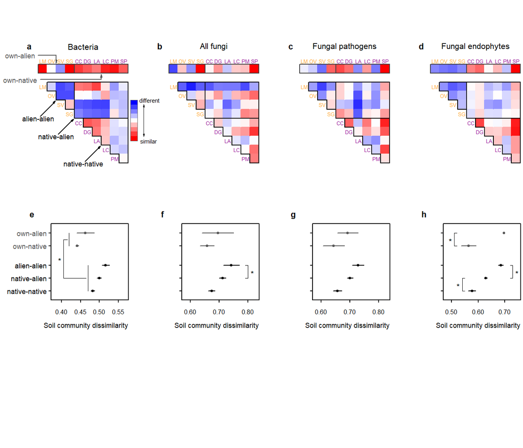

```r
# pdf('./fig/cor_plot_sp_t.pdf', height = 6, width = 18/2.54, useDingbats=FALSE)
par(mfrow = c(2,4),xpd = T)
plot_cor(beta_mat_sp_16s_nonster,title = 'Bacteria')
# text
text(-0.5,13.5, 'own-alien', cex = 0.85, col = 'gray35')
segments(1.45, 13.5, 3.5, 13.5, col = 'gray35')
Arrows(3.5,13.5, 3.5, 12.8, arr.type="triangle", arr.length = 0.05, col = 'gray35')

text(-0.5, 10.8, 'own-native', cex = 0.85, col = 'gray35')
segments(1.7,10.8, 8.5, 10.8, col = 'gray35')
Arrows(8.5,10.8, 8.5, 11.2, arr.type="triangle", arr.length = 0.05, col = 'gray35')

text(1.5,6.5, 'alien-alien', cex = 0.85)
Arrows(1.7, 6.7, 3.3, 8.3, arr.type="triangle", arr.length = 0.05)
text(3.5, 4.5, 'native-alien', cex = 0.85)
Arrows(3.7, 4.7, 5.3, 6.3, arr.type="triangle", arr.length = 0.05)
text(6.5, 1.5, 'native-native', cex = 0.85)
Arrows(6.7, 1.7, 8.3, 3.3, arr.type="triangle", arr.length = 0.05)


# fungi
plot_cor(beta_mat_sp_its_nonster,title = 'All fungi', tag = 'b')
# color scale
rect(-2, 9 - 0.5*1:9, -2.8, 8.5 - 0.5*1:9, col =
       colorRampPalette(c("red","white","blue"))(200)[c(8:1*25,1)], border = NA)
rect(-2, 8.5, -2.8, 4, lwd = 0.5, border = 'gray39')
text(-1.8, 8.5, adj = c(0,NA), 'different', cex = 0.7)
text(-1.7, 4, adj = c(0, NA),  'similar', cex = 0.7)
Arrows(- 1.3,7.9, -1.3, 4.6, arr.type="triangle", arr.length = 0.05, code = 3, lwd = 0.5) # connect different and similar


# pathogen
plot_cor(beta_mat_sp_its_nonster_pathogen,title = 'Fungal pathogens', tag = 'c')

# endophytes
plot_cor(beta_mat_sp_its_nonster_endo,title = 'Fungal endophytes', tag = 'd')

# forest plots
par(mar = c(15, 5.2, 0, 0.2), xpd = T)
forest_beta_t(title = '', ylab = T)
segments(0.42, 5.5, 0.42, 4.5, lwd = 0.75)
segments(0.47, 3,   0.47, 1,   lwd = 0.75)
segments(0.415, 2,   0.465, 2, lwd = 0.75)
brackets(0.415, 5,   0.415, 2,   type = 4, h = -0.01, ticks = NA, lwd = 0.75)
text(0.415-0.02, 3.5, '*')

forest_beta_t(beta_mat = beta_mat_sp_its_nonster, title = '', xaxt = c(0.6, 0.7, 0.8), xlim = c(0.58,0.83),
            tag = 'f')
brackets(0.79, 3, 0.79, 2,   type = 4, h = 0.01, ticks = NA, lwd = 0.75)
text(0.815, 2.5, '*')
# brackets(0.65, 2, 0.65, 1,   type = 4, h = -0.01, ticks = NA, lwd = 0.75)
# text(0.625, 1.5, '\u2020')

forest_beta_t(beta_mat = beta_mat_sp_its_nonster_pathogen, title = '', xaxt = c(0.6, 0.7, 0.8),xlim = c(0.58,0.83),
            tag = 'g')
forest_beta_t(beta_mat = beta_mat_sp_its_nonster_endo, title = '', xaxt = c(0.5, 0.6, 0.7),xlim = c(0.48,0.75),
            tag = 'h')
brackets(0.72, 3, 0.72, 2,   type = 4, h = 0.01, ticks = NA, lwd = 0.75)
text(0.745, 2.5, '*')
brackets(0.55, 2, 0.55, 1,   type = 4, h = -0.01, ticks = NA, lwd = 0.75)
text(0.525, 1.5, '*')
brackets(0.52, 5.5, 0.52, 4.5,   type = 4, h = -0.01, ticks = NA, lwd = 0.75)
text(0.495, 5, '*')
```

```r
# dev.off()
```

### 4.3.2 two subsets of endophytes (Extended Fig. 5a-d)

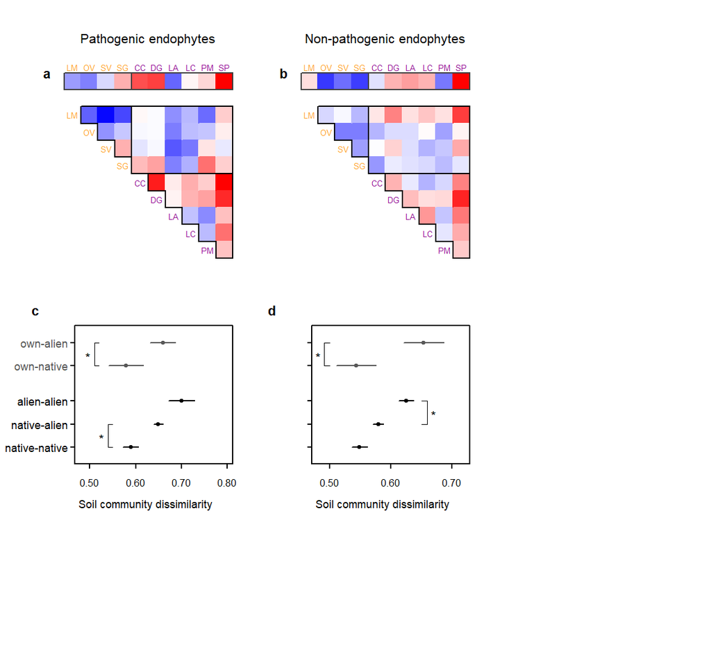

```r
# pdf('./fig/cor_plot_sp_endo_t.pdf',height = 6, width = 17/2.54,  useDingbats=FALSE)
par(mfrow = c(2,3),xpd = T)
plot_cor(beta_mat_sp_its_nonster_endo_path,title = 'Pathogenic endophytes')
plot_cor(beta_mat_sp_its_nonster_endo_no_path,title = 'Non-pathogenic endophytes', tag = 'b')
plot.new()
par(mar = c(12, 4.8, 0, 0.25), xpd = T)
forest_beta_t(beta_mat = beta_mat_sp_its_nonster_endo_path, title = '', ylab = T, tag = 'c',
               xaxt = c(0.5, 0.6, 0.7, 0.8), xlim = c(0.48,0.8))

brackets(0.55, 2, 0.55, 1,   type = 4, h = -0.01, ticks = NA, lwd = 0.75)
text(0.525, 1.5, '*')
brackets(0.52, 5.5, 0.52, 4.5,   type = 4, h = -0.01, ticks = NA, lwd = 0.75)
text(0.495, 5, '*')

forest_beta_t(beta_mat = beta_mat_sp_its_nonster_endo_no_path, title = '',
              xaxt = c(0.5, 0.6, 0.7), xlim = c(0.48,0.72),tag = 'd')

brackets(0.65, 3, 0.65, 2,   type = 4, h = 0.01, ticks = NA, lwd = 0.75)
text(0.67, 2.5, '*')
brackets(0.5, 5.5, 0.5, 4.5,   type = 4, h = -0.01, ticks = NA, lwd = 0.75)
text(0.48, 5, '*')
# dev.off()
```

### 4.3.3 sterilized soils (Extended Fig. 7)

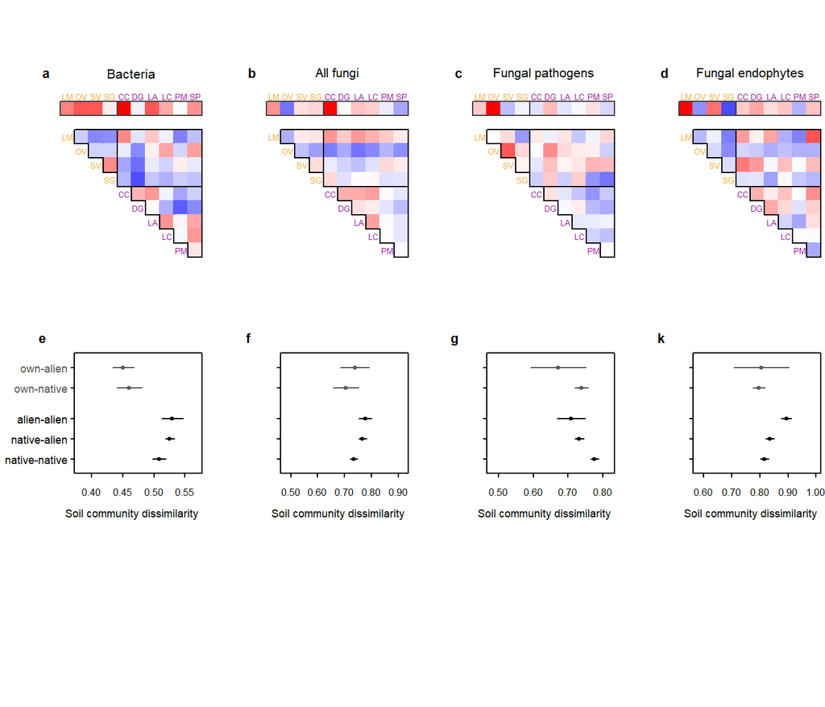

```r
# pdf('./fig/cor_plot_sp_ster_t.pdf',height = 6, width = 18/2.54, useDingbats=FALSE)
par(mfrow = c(2,4),xpd = T)
plot_cor(beta_mat_sp_16s_ster,title = 'Bacteria')
plot_cor(beta_mat_sp_its_ster,title = 'All fungi', tag = 'b')
plot_cor(beta_mat_sp_its_ster_pathogen,title = 'Fungal pathogens', tag = 'c')
plot_cor(beta_mat_sp_its_ster_endo,title = 'Fungal endophytes', tag = 'd')

par(mar = c(15, 4.8, 0, 0.25), xpd = T)
forest_beta_t(beta_mat = beta_mat_sp_16s_ster, title = '', ylab = T, tag = 'e')
forest_beta_t(beta_mat = beta_mat_sp_its_ster, title = '',
              xaxt = c(0.5, 0.6, 0.7, 0.8, 0.9), xlim = c(0.48,0.92), tag = 'f')
forest_beta_t(beta_mat = beta_mat_sp_its_ster_pathogen, title = '',
              xaxt = c(0.5, 0.6, 0.7, 0.8),xlim = c(0.48,0.82), tag = 'g')
forest_beta_t(beta_mat = beta_mat_sp_its_ster_endo, title = '',
              xaxt = c(0.1*6:10),xlim = c(0.58,1), tag = 'k')
```

```r
# dev.off()
```

export tables

```r
# write.csv(cbind(t_beta_16s, t_beta_its, t_beta_its_path, t_beta_its_endo,
#                 t_beta_16s_ster, t_beta_its_ster, t_beta_its_path_ster, t_beta_its_endo_ster),
#           './table/table_beta.csv')
#
# write.csv(cbind( t_beta_its_endo_path,t_beta_its_endo_no_path),
#           './table/table_beta_two_endo.csv')
```

# 5 alpha diversity and abundance

**This section aims to test whether present of plants and the origin of the plants affect the alpha diversity (species richness and Shannon diversity) of soil microbes and abundance of fungal pathogens.**

Note that, the abundance is ‘relative’ abundance, so it cannot be applied to whole bacteria and fungi.

```r
#get diversity for each species
alpha_16s <- alpha_div(otu_table_16s,sam_table_16s)
alpha_its <- alpha_div(otu_table_its,sam_table_its)

# its different functional groups
its_func_sub <- its_func %>%
  filter(OTU_ID %in% as.character(colnames(otu_table_its)))

otu_table_its_pathogen <- otu_table_its[,as.character(its_func_sub$OTU_ID[its_func_sub[,'pathogen'] == 'pathogen'])]
alpha_its_pathogen <-alpha_div(otu_table_its_pathogen, sam_table_its)
```

## 5.1 non-sterilized soil

Overall, aliens and natives did not differ in diversity of fungi and bacteria

```r
m_16s_sr <-lme((sr)~ T1_empty + T2_alien_native + trans_date_c,
               random = ~ 1|family/species,
               data = alpha_16s %>% filter(ster.not =='nonster'),
               # weights = varIdent(form = ~1|species), # weight did not improve the model
               method = 'ML'
              )
m_16s_sha <-update(m_16s_sr,shannon ~., control = lmeControl(msMaxIter = 1000))


m_its_sr  <- update(m_16s_sr,.~., data = alpha_its %>% filter(ster.not =='nonster'))
m_its_sha <- update(m_its_sr,shannon ~.)

m_its_pathogen_sr <- update(m_its_sr, data = alpha_its_pathogen %>% filter(ster.not == 'nonster'))
m_its_pathogen_sha <-update(m_its_pathogen_sr,shannon~.)
```

```r
drop1_div <- function(model){
  r1 <- drop1(model, test = 'Chisq')[-c(1,4),]
  r2 <- drop1(update(model,.~trans_date_c), test = 'Chisq')[-1,]
  return(merge_fix_rand(rbind(r2,r1), model, nest = T))

}
t_div_nonster <- lapply(list(m_16s_sr, m_16s_sha,
                             m_its_sr, m_its_sha,
                             m_its_pathogen_sr, m_its_pathogen_sha),
                        drop1_div)
```

### 5.1.1 diversity of 16s (bacteria)

```r
print('Species richness');  t_div_nonster[[1]] %>% kable
```

```
## [1] "Species richness"
```

|  | X2 | P |
| --- | --- | --- |
| trans_date_c | 0.298 | 0.585 |
| T1_empty | 0.647 | 0.421 |
| T2_alien_native | 0.180 | 0.671 |
| Random effects | SD |  |
| Family | 0.045 |  |
| Species | 0.057 |  |
| Residual | 601.913 |  |

```r
print('Shannon diversity'); t_div_nonster[[2]] %>% kable
```

```
## [1] "Shannon diversity"
```

|  | X2 | P |
| --- | --- | --- |
| trans_date_c | 5.329 | 0.021* |
| T1_empty | 0.001 | 0.982 |
| T2_alien_native | 0.211 | 0.646 |
| Random effects | SD |  |
| Family | 0.000 |  |
| Species | 0.000 |  |
| Residual | 0.255 |  |

### 5.1.2 diversity of its (fungi)

all fungi

```r
print('Species richness');  t_div_nonster[[3]] %>% kable
```

```
## [1] "Species richness"
```

|  | X2 | P |
| --- | --- | --- |
| trans_date_c | 7.911 | 0.005* |
| T1_empty | 0.058 | 0.809 |
| T2_alien_native | 0.386 | 0.535 |
| Random effects | SD |  |
| Family | 0.001 |  |
| Species | 0.001 |  |
| Residual | 28.912 |  |

```r
print('Shannon diversity'); t_div_nonster[[4]] %>% kable
```

```
## [1] "Shannon diversity"
```

|  | X2 | P |
| --- | --- | --- |
| trans_date_c | 2.789 | 0.095† |
| T1_empty | 0.260 | 0.610 |
| T2_alien_native | 1.375 | 0.241 |
| Random effects | SD |  |
| Family | 0.000 |  |
| Species | 0.000 |  |
| Residual | 0.588 |  |

fungal pathogens

```r
print('Species richness');  t_div_nonster[[5]] %>% kable
```

```
## [1] "Species richness"
```

|  | X2 | P |
| --- | --- | --- |
| trans_date_c | 8.487 | 0.004* |
| T1_empty | 0.144 | 0.704 |
| T2_alien_native | 0.008 | 0.930 |
| Random effects | SD |  |
| Family | 0.000 |  |
| Species | 1.585 |  |
| Residual | 5.975 |  |

```r
print('Shannon diversity'); t_div_nonster[[6]] %>% kable
```

```
## [1] "Shannon diversity"
```

|  | X2 | P |
| --- | --- | --- |
| trans_date_c | 0.364 | 0.546 |
| T1_empty | 0.038 | 0.845 |
| T2_alien_native | 0.002 | 0.966 |
| Random effects | SD |  |
| Family | 0.000 |  |
| Species | 0.000 |  |
| Residual | 0.587 |  |

### 5.1.3 abundance of fungal pathogens

overview in both sterilized and non-sterilized soils

```r
print(paste('total diversity = ',length(otu_table_its)))
```

```
## [1] "total diversity =  2421"
```

```r
rel_abun(otu_table_its,its_func,'assigned')
```

```
## [1] "% abundance of assigned = 0.272004828585225"
## [1] "# diversity of assigned = 889"
## [1] "% diversity of assigned = 0.367203634861627"
```

```r
rel_abun(otu_table_its,its_func,'pathogen')
```

```
## [1] "% abundance of pathogen = 0.150975374215355"
## [1] "# diversity of pathogen = 250"
## [1] "% diversity of pathogen = 0.103263114415531"
```

```r
rel_abun(otu_table_its,its_func,'AMF')
```

```
## [1] "% abundance of AMF = 0.00103235152100435"
## [1] "# diversity of AMF = 50"
## [1] "% diversity of AMF = 0.0206526228831062"
```

```r
rel_abun(otu_table_its,its_func,'endo')
```

```
## [1] "% abundance of endo = 0.103225494929986"
## [1] "# diversity of endo = 165"
## [1] "% diversity of endo = 0.0681536555142503"
```

```r
rel_abun(otu_table_its,its_func,'endo_path')
```

```
## [1] "% abundance of endo_path = 0.0483341380975374"
## [1] "# diversity of endo_path = 78"
## [1] "% diversity of endo_path = 0.0322180916976456"
```

```r
rel_abun(otu_table_its,its_func,'endo_no_path')
```

```
## [1] "% abundance of endo_no_path = 0.0548913568324481"
## [1] "# diversity of endo_no_path = 87"
## [1] "% diversity of endo_no_path = 0.0359355638166047"
```

only nonster

```r
print(paste('total diversity = ',length(otu_table_its_nonster)))
```

```
## [1] "total diversity =  2421"
```

```r
rel_abun(otu_table_its_nonster,its_func_nonster, 'assigned')
```

```
## [1] "% abundance of assigned = 0.300451612903226"
## [1] "# diversity of assigned = 889"
## [1] "% diversity of assigned = 0.367203634861627"
```

```r
rel_abun(otu_table_its_nonster,its_func_nonster, 'pathogen')
```

```
## [1] "% abundance of pathogen = 0.114499151103565"
## [1] "# diversity of pathogen = 250"
## [1] "% diversity of pathogen = 0.103263114415531"
```

```r
rel_abun(otu_table_its_nonster,its_func_nonster, 'AMF')
```

```
## [1] "% abundance of AMF = 0.000492359932088285"
## [1] "# diversity of AMF = 50"
## [1] "% diversity of AMF = 0.0206526228831062"
```

```r
rel_abun(otu_table_its_nonster,its_func_nonster, 'endo')
```

```
## [1] "% abundance of endo = 0.157446519524618"
## [1] "# diversity of endo = 165"
## [1] "% diversity of endo = 0.0681536555142503"
```

```r
rel_abun(otu_table_its_nonster,its_func_nonster, 'endo_path')
```

```
## [1] "% abundance of endo_path = 0.0635942275042445"
## [1] "# diversity of endo_path = 78"
## [1] "% diversity of endo_path = 0.0322180916976456"
```

```r
rel_abun(otu_table_its_nonster,its_func_nonster, 'endo_no_path')
```

```
## [1] "% abundance of endo_no_path = 0.0938522920203735"
## [1] "# diversity of endo_no_path = 87"
## [1] "% diversity of endo_no_path = 0.0359355638166047"
```

```r
abun_its_pathogen <- abun_by_pot(otu_table_its_pathogen,info_its)
```

models

```r
# not sterilized
model  <- lme(logit(rel_abu)~ T1_empty + T2_alien_native + trans_date_c, random = ~1|family/species,
              weights = varIdent(form = ~1|species),
              data = abun_its_pathogen %>% filter(ster.not == 'nonster'),method = 'ML')
# sterilized
model2 <- update(model, .~. + trans_date_c, data = abun_its_pathogen %>% filter(ster.not == 'ster'))

t_abundance <- lapply(list(model, model2), drop1_div)
```

```r
t_abundance[[1]] %>% kable()
```

|  | X2 | P |
| --- | --- | --- |
| trans_date_c | 11.932 | 0.001* |
| T1_empty | 1.325 | 0.250 |
| T2_alien_native | 0.002 | 0.967 |
| Random effects | SD |  |
| Family | 0.000 |  |
| Species | 0.000 |  |
| Residual | 1.043 |  |

## 5.2 sterilized

```r
m_16s_sr<-lme((sr)~ T1_empty + T2_alien_native + trans_date_c,random = ~ 1|family/species,
              data = alpha_16s %>% filter(ster.not =='ster'),
              # weights = varIdent(form = ~1|species), # weight did not improve the model
              method = 'ML')
m_16s_sha<-update(m_16s_sr,shannon ~., control = lmeControl(msMaxIter = 1000))


m_its_sr  <- update(m_16s_sr,.~., data = alpha_its %>% filter(ster.not =='ster'))
m_its_sha <- update(m_its_sr,shannon ~.)


m_its_pathogen_sr <- update(m_its_sr, data = alpha_its_pathogen %>% filter(ster.not == 'ster'))
m_its_pathogen_sha <-update(m_its_pathogen_sr, shannon~.)


t_div_ster <- lapply(list(m_16s_sr, m_16s_sha,
                             m_its_sr, m_its_sha,
                             m_its_pathogen_sr, m_its_pathogen_sha),
                        drop1_div)
```

### 5.2.1 diversity of 16s (bacteria)

```r
print('Species richness');  t_div_ster[[1]] %>% kable
```

```
## [1] "Species richness"
```

|  | X2 | P |
| --- | --- | --- |
| trans_date_c | 0.174 | 0.676 |
| T1_empty | 13.548 | 0.000* |
| T2_alien_native | 0.795 | 0.373 |
| Random effects | SD |  |
| Family | 0.014 |  |
| Species | 0.016 |  |
| Residual | 336.203 |  |

```r
print('Shannon diversity'); t_div_ster[[2]] %>% kable
```

```
## [1] "Shannon diversity"
```

|  | X2 | P |
| --- | --- | --- |
| trans_date_c | 2.561 | 0.109 |
| T1_empty | 8.389 | 0.004* |
| T2_alien_native | 2.215 | 0.137 |
| Random effects | SD |  |
| Family | 0.000 |  |
| Species | 0.000 |  |
| Residual | 0.172 |  |

### 5.2.2 diversity of its (fungi)

all fungi

```r
print('Species richness');  t_div_ster[[3]] %>% kable
```

```
## [1] "Species richness"
```

|  | X2 | P |
| --- | --- | --- |
| trans_date_c | 0.000 | 0.988 |
| T1_empty | 0.392 | 0.531 |
| T2_alien_native | 4.368 | 0.037* |
| Random effects | SD |  |
| Family | 7.455 |  |
| Species | 0.001 |  |
| Residual | 15.038 |  |

```r
print('Shannon diversity'); t_div_ster[[4]] %>% kable
```

```
## [1] "Shannon diversity"
```

|  | X2 | P |
| --- | --- | --- |
| trans_date_c | 0.588 | 0.443 |
| T1_empty | 0.841 | 0.359 |
| T2_alien_native | 0.983 | 0.322 |
| Random effects | SD |  |
| Family | 0.000 |  |
| Species | 0.000 |  |
| Residual | 0.542 |  |

fungal pathogens

```r
print('Species richness');  t_div_ster[[5]] %>% kable
```

```
## [1] "Species richness"
```

|  | X2 | P |
| --- | --- | --- |
| trans_date_c | 2.601 | 0.107 |
| T1_empty | 4.250 | 0.039* |
| T2_alien_native | 6.707 | 0.010* |
| Random effects | SD |  |
| Family | 0.000 |  |
| Species | 0.938 |  |
| Residual | 3.807 |  |

```r
print('Shannon diversity'); t_div_ster[[6]] %>% kable
```

```
## [1] "Shannon diversity"
```

|  | X2 | P |
| --- | --- | --- |
| trans_date_c | 2.911 | 0.088† |
| T1_empty | 1.390 | 0.238 |
| T2_alien_native | 2.340 | 0.126 |
| Random effects | SD |  |
| Family | 0.151 |  |
| Species | 0.000 |  |
| Residual | 0.542 |  |

### 5.2.3 abundance of fungal pathogens

```r
t_abundance[[2]] %>% kable()
```

|  | X2 | P |
| --- | --- | --- |
| trans_date_c | 2.800 | 0.094† |
| T1_empty | 2.537 | 0.111 |
| T2_alien_native | 1.379 | 0.240 |
| Random effects | SD |  |
| Family | 0.000 |  |
| Species | 0.000 |  |
| Residual | 0.843 |  |

## 5.3 Figures (Extended Fig. 3)

```r
# -------------diversity------------#
# bacteria
p_alpha_16s_sr   <- boxplot_div(table_alpha = alpha_16s, title = 'Bacteria', tag = 'a')
p_alpha_16s_shan <- boxplot_div(table_alpha = alpha_16s, title = '',
                  y = 'shannon', ylab = 'Shannon diversity', tag = 'd')

# all fungi
p_alpha_its_sr   <- boxplot_div(table_alpha = alpha_its, title = 'All fungi', tag = 'b', ylab = ' ')
p_alpha_its_shan <- boxplot_div(table_alpha = alpha_its, title = '',
                  y = 'shannon', ylab = ' ', tag = 'e')

# fungal pathogens
p_alpha_its_pathogen_sr <- boxplot_div(table_alpha = alpha_its_pathogen, title = 'Fungal pathogens', tag = 'c', ylab = ' ')
p_alpha_its_pathogen_shan <- boxplot_div(table_alpha = alpha_its_pathogen, title = '', y = 'shannon', ylab = ' ', tag = 'f')

# --------abundance -------#
p1 <- boxplot_div(abun_its_pathogen, y = 'rel_abu', title = 'Fungal pathogens',ylab = 'Relative abundance', tag = 'g')
```

```r
# ggsave('./fig/alpha.pdf', height = 7, width = 18/2.54,
#        grid.arrange(p_alpha_16s_sr,   p_alpha_its_sr,   p_alpha_its_pathogen_sr,
#                     p_alpha_16s_shan, p_alpha_its_shan, p_alpha_its_pathogen_shan,
#                     p1,
#                     layout_matrix = matrix(c(1:6, NA, NA, 7), nrow =3, ncol = 3, byrow = T)),  useDingbats=FALSE)
```

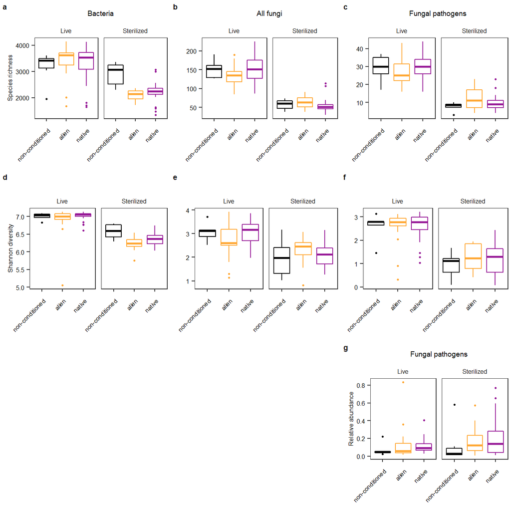

```r
grid.arrange(p_alpha_16s_sr,   p_alpha_its_sr,   p_alpha_its_pathogen_sr,
             p_alpha_16s_shan, p_alpha_its_shan, p_alpha_its_pathogen_shan,
             p1,
             layout_matrix = matrix(c(1:6, NA, NA, 7), nrow =3, ncol = 3, byrow = T))
```

export tables

```r
# write.csv(t_div_nonster, './table/t_div_nonster.csv') # diversity (not sterilized)
# write.csv(t_div_ster,    './table/t_div_ster.csv') # diversity (sterilized)
#
# write.csv(t_abundance, './table/t_abundance.csv') # abundance
```

# 6 soil-legacy effect ~ soil communities

**This section aims to test which aspect of soil communities (alpha, $\alpha$) can explain the soil-legacy effect (beta, $\beta$).**  
I tested two aspects: novel interaction (dissimilarity between soil communities) and enemy release (diversity and abundance of soil microbes).

data prep

```r
beta_16s_combi<-beta_mat_sp_16s_nonster%>%
  mutate(combi = ifelse(sp1 < sp2,paste(sp1,sp2),paste(sp2,sp1)))%>%# get a order, sp1 is the soil species, and sp2 is the test species
  ungroup()%>%
  dplyr::select(combi,mean_beta)%>%
  dplyr::rename(beta_16s = mean_beta)
beta_its_combi<-beta_mat_sp_its_nonster%>%
  mutate(combi = ifelse(sp1 < sp2,paste(sp1,sp2),paste(sp2,sp1)))%>%# get a order
  ungroup()%>%
  dplyr::select(combi,mean_beta)%>%
  dplyr::rename(beta_its = mean_beta)
beta_its_pathogen_combi<-beta_mat_sp_its_nonster_pathogen%>%
  mutate(combi = ifelse(sp1 < sp2,paste(sp1,sp2),paste(sp2,sp1)))%>%# get a order
  ungroup()%>%
  dplyr::select(combi,mean_beta)%>%
  dplyr::rename(beta_its_pathogen = mean_beta)
beta_its_endo_combi<-beta_mat_sp_its_nonster_endo%>%
  mutate(combi = ifelse(sp1 < sp2,paste(sp1,sp2),paste(sp2,sp1)))%>%# get a order
  ungroup()%>%
  dplyr::select(combi,mean_beta)%>%
  dplyr::rename(beta_its_endo = mean_beta)
beta_its_endo_path_combi<-beta_mat_sp_its_nonster_endo_path%>%
  mutate(combi = ifelse(sp1 < sp2,paste(sp1,sp2),paste(sp2,sp1)))%>%# get a order
  ungroup()%>%
  dplyr::select(combi,mean_beta)%>%
  dplyr::rename(beta_its_endo_path = mean_beta)
beta_its_endo_no_path_combi<-beta_mat_sp_its_nonster_endo_no_path%>%
  mutate(combi = ifelse(sp1 < sp2,paste(sp1,sp2),paste(sp2,sp1)))%>%# get a order
  ungroup()%>%
  dplyr::select(combi,mean_beta)%>%
  dplyr::rename(beta_its_endo_no_path = mean_beta)



# abundance of pathogen
abun_path <- abun_its_pathogen %>%
  filter(ster.not == 'nonster') %>%
  group_by(species) %>%
  summarise(abun_path = mean(rel_abu))

# alpha diversity
div_path <- alpha_its_pathogen %>%
  filter(ster.not == 'nonster') %>%
  dplyr::select(sr, shannon, species) %>%
  group_by(species) %>%
  summarise(div_path_sr = mean(sr),
            div_path_shan = mean(shannon))

div_its <- alpha_its %>%
  filter(ster.not == 'nonster') %>%
  dplyr::select(sr, shannon, species) %>%
  group_by(species) %>%
  summarise(div_its_sr = mean(sr),
            div_its_shan = mean(shannon))

div_16s <- alpha_16s %>%
  filter(ster.not == 'nonster') %>%
  dplyr::select(sr, shannon, species) %>%
  group_by(species) %>%
  summarise(div_16s_sr = mean(sr),
            div_16s_shan = mean(shannon))
```

data merge. The `legacy_alone` is the soil-legacy effect (beta_alone in Fig. 1), which is calculated from the test plants that were grown alone

sp_p1: soil species  
sp_p2: test species

```r
dat_legacy_alone <- dat_legacy_alone %>%
  mutate(sp_p1 = as.character(sp_p1),sp_p2 = as.character(sp_p2))%>%
  mutate(combi = ifelse(sp_p1 < sp_p2, paste(sp_p1,sp_p2), paste(sp_p2,sp_p1))) %>% # unique set
  left_join(beta_16s_combi) %>%
  left_join(beta_its_combi) %>%
  left_join(beta_its_pathogen_combi) %>%
  left_join(beta_its_endo_combi) %>%
  left_join(beta_its_endo_path_combi) %>%
  left_join(beta_its_endo_no_path_combi) %>%
  left_join(abun_path, by = c('sp_p1' = 'species')) %>%
  left_join(div_path,  by = c('sp_p1' = 'species')) %>%
  left_join(div_16s,   by = c('sp_p1' = 'species')) %>%
  left_join(div_its,   by = c('sp_p1' = 'species')) %>%
  mutate(combi_status = ifelse(origin_p1 == 'native' & origin_p2 == 'native','native-native',
                               ifelse(origin_p1 == 'alien' & origin_p2 == 'alien','alien-alien','native-alien'))) %>%
  mutate(intra_inter = ifelse(sp_p1 != sp_p2, 0 , 1))
```

The `legacy_stren` is also soil-legacy effect. But it is the beta_intra and beta_inter in Fig. 1), which describes the effect of soil species on strength of competition in test plants.

sp_p2_comp: competitor test species

```r
dat_legacy_stren <- dat_legacy_stren %>%
  mutate(sp_p1 = as.character(sp_p1), sp_p2 = as.character(sp_p2), sp_p2_comp = as.character(sp_p2_comp)) %>%
  mutate(combi_p1_target = ifelse(sp_p1 < sp_p2,      paste(sp_p1, sp_p2),      paste(sp_p2, sp_p1)),
         combi_p1_comp   = ifelse(sp_p1 < sp_p2_comp, paste(sp_p1, sp_p2_comp), paste(sp_p2_comp, sp_p1)),
         combi_p2        = ifelse(sp_p2 < sp_p2_comp, paste(sp_p2, sp_p2_comp), paste(sp_p2_comp, sp_p2))) %>%
  left_join(abun_path, by = c('sp_p1' = 'species')) %>%
  left_join(div_path,  by = c('sp_p1' = 'species')) %>%
  left_join(div_16s,   by = c('sp_p1' = 'species')) %>%
  left_join(div_its,   by = c('sp_p1' = 'species')) %>%
  # as we have three individual in each system, we will have three beta diversities for each type of beta diversity
  # i.e. beta diversity between soil (p1) individual and test focal individual (_p1_target), between soil individual and test competitor individual (_p1_comp), and between test individuals (_p2)
  left_join(beta_16s_combi, by = c('combi_p1_target' = 'combi')) %>% rename(beta_16s_p1_target = beta_16s) %>%
  left_join(beta_16s_combi, by = c('combi_p1_comp'   = 'combi')) %>% rename(beta_16s_p1_comp   = beta_16s) %>%
  left_join(beta_16s_combi, by = c('combi_p2'        = 'combi')) %>% rename(beta_16s_p2        = beta_16s) %>%

  left_join(beta_its_combi, by = c('combi_p1_target' = 'combi')) %>% rename(beta_its_p1_target = beta_its) %>%
  left_join(beta_its_combi, by = c('combi_p1_comp'   = 'combi')) %>% rename(beta_its_p1_comp = beta_its) %>%
  left_join(beta_its_combi, by = c('combi_p2'        = 'combi')) %>% rename(beta_its_p2 = beta_its) %>%

  left_join(beta_its_pathogen_combi, by = c('combi_p1_target' = 'combi')) %>% rename(beta_its_path_p1_target = beta_its_pathogen) %>%
  left_join(beta_its_pathogen_combi, by = c('combi_p1_comp'   = 'combi')) %>% rename(beta_its_path_p1_comp = beta_its_pathogen) %>%
  left_join(beta_its_pathogen_combi, by = c('combi_p2'        = 'combi')) %>% rename(beta_its_path_p2 = beta_its_pathogen) %>%

  left_join(beta_its_endo_combi, by = c('combi_p1_target' = 'combi')) %>% rename(beta_its_endo_p1_target = beta_its_endo) %>%
  left_join(beta_its_endo_combi, by = c('combi_p1_comp'   = 'combi')) %>% rename(beta_its_endo_p1_comp = beta_its_endo) %>%
  left_join(beta_its_endo_combi, by = c('combi_p2'        = 'combi')) %>% rename(beta_its_endo_p2 = beta_its_endo) %>%

  # interspecific competition or inter
  mutate(intra_inter = ifelse(sp_p2 != sp_p2_comp, 'inter', 'intra'))
```

## 6.1 novel interaction

whether beta_alone/beta_intra/beta_inter is correlated with soil-community-dissimilarity between plants

### 6.1.1 beta_alone (Fig. 5)

legacy effect ~ beta diversity

```r
dat_legacy_alone_na <- dat_legacy_alone %>%
  filter(!is.na(beta_16s))
```

```r
u<-gl(1,1,length(dat_legacy_alone_na$biomass))

model <- lme(legacy_alone ~ logit(beta_16s),
             random=list(u=pdBlocked(list(pdIdent(form=~family_p1-1), pdIdent(form=~sp_p1-1),
                                          pdIdent(form=~family-1), pdIdent(form=~sp_p2-1)))),
             data=dat_legacy_alone_na,
             weights = varComb(varIdent(form = ~1|sp_p2),
                               varIdent(form = ~ 1|sp_p1)),
             control = lmeControl(msMaxIter = 1000),
             method = "ML")

model2 <- update(model,.~ logit(beta_its))
model3 <- update(model,.~ logit(beta_its_pathogen))
model4 <- update(model,.~ logit(beta_its_endo))
model5 <- update(model,.~ logit(beta_its_endo_path))
model6 <- update(model,.~ logit(beta_its_endo_no_path), weights = varIdent(form = ~1|sp_p1)) # including varident for sp_p2 prevents the model from converging. So I simplied the model. (neither 'optim' nor 'nlminb' works)
```

export table

```r
#tables
t_dis_16s  <- merge_fix_rand(drop1(model,  test = 'Chisq')[-1,], model)
t_dis_its  <- merge_fix_rand(drop1(model2, test = 'Chisq')[-1,], model2)
t_dis_path <- merge_fix_rand(drop1(model3, test = 'Chisq')[-1,], model3)
t_dis_endo <- merge_fix_rand(drop1(model4, test = 'Chisq')[-1,], model4)

# two subsets of endophytes
t_dis_endo_path    <- merge_fix_rand(drop1(model5, test = 'Chisq')[-1,], model4)
t_dis_endo_no_path <- merge_fix_rand(drop1(model6, test = 'Chisq')[-1,], model4)

# write.csv(rbind(t_dis_16s,t_dis_its, t_dis_path, t_dis_endo, t_dis_endo_path, t_dis_endo_no_path), './table/psf~dis.csv')
```

```r
print('PSF ~ similarity in bacteria'); t_dis_16s %>% kable
```

```
## [1] "PSF ~ similarity in bacteria"
```

|  | X2 | P |
| --- | --- | --- |
| logit(beta_16s) | 2.777 | 0.096† |
| Random effects | SD |  |
| family_p1 | 0.186 |  |
| sp_p1 | 0.000 |  |
| family | 0.107 |  |
| sp_p2 | 0.020 |  |
| Residual | 0.238 |  |

```r
print('PSF ~ similarity in Fungi');    t_dis_its %>% kable
```

```
## [1] "PSF ~ similarity in Fungi"
```

|  | X2 | P |
| --- | --- | --- |
| logit(beta_its) | 2.565 | 0.109 |
| Random effects | SD |  |
| family_p1 | 0.184 |  |
| sp_p1 | 0.000 |  |
| family | 0.141 |  |
| sp_p2 | 0.000 |  |
| Residual | 0.260 |  |

```r
print('PSF ~ similarity in pathogen'); t_dis_path %>% kable
```

```
## [1] "PSF ~ similarity in pathogen"
```

|  | X2 | P |
| --- | --- | --- |
| logit(beta_its_pathogen) | -0.083 | 1.000 |
| Random effects | SD |  |
| family_p1 | 0.160 |  |
| sp_p1 | 0.000 |  |
| family | 0.000 |  |
| sp_p2 | 0.121 |  |
| Residual | 0.315 |  |

```r
print('PSF ~ similarity in endophytes'); t_dis_endo %>% kable
```

```
## [1] "PSF ~ similarity in endophytes"
```

|  | X2 | P |
| --- | --- | --- |
| logit(beta_its_endo) | 7.490 | 0.006* |
| Random effects | SD |  |
| family_p1 | 0.193 |  |
| sp_p1 | 0.060 |  |
| family | 0.164 |  |
| sp_p2 | 0.000 |  |
| Residual | 0.241 |  |

```r
print('two subsets of endophytes: pathogenic endophytes and non-pathogenic endophytes')
```

```
## [1] "two subsets of endophytes: pathogenic endophytes and non-pathogenic endophytes"
```

```r
t_dis_endo_path %>% kable;  t_dis_endo_no_path %>% kable
```

|  | X2 | P |
| --- | --- | --- |
| logit(beta_its_endo_path) | 5.609 | 0.018* |
| Random effects | SD |  |
| family_p1 | 0.193 |  |
| sp_p1 | 0.060 |  |
| family | 0.164 |  |
| sp_p2 | 0.000 |  |
| Residual | 0.241 |  |

|  | X2 | P |
| --- | --- | --- |
| logit(beta_its_endo_no_path) | 0.384 | 0.536 |
| Random effects | SD |  |
| family_p1 | 0.193 |  |
| sp_p1 | 0.060 |  |
| family | 0.164 |  |
| sp_p2 | 0.000 |  |
| Residual | 0.241 |  |

```r
model  <-update(model,  method  = 'REML')
model4 <-update(model4, method = 'REML')
model5 <-update(model5, method = 'REML')
```

```r
# r.squaredGLMM(model)
# r.squaredGLMM(model2)
# r.squaredGLMM(model3)
# r.squaredGLMM(model4)
# r.squaredGLMM(model5)
# r.squaredGLMM(model6)
```

```r
ylimits = c(-1.52,0.72)
ylab = expression(paste('Soil-legacy effect (', italic(beta['alone']), ')','\n', sep = ''))
p1 <- dat_legacy_alone_na %>%
  ggplot() + aes(x = logit(beta_16s), y = legacy_alone) + geom_point(size = 0.8) +
  labs(x = '\nSoil community dissmilarity', y = ylab, title = 'Bacteria', tag = 'a') +
  theme +
  geom_abline(intercept = summary(model)$coef$fixed[1], slope = summary(model)$coef$fixed[2], linetype = 2) +
  scale_x_continuous(breaks = c(-0.3, -0.1, 0.1), labels = c(-0.3, -0.1, 0.1)) +
  scale_y_continuous(limits = ylimits) +
  annotate("text", label = expression(italic(paste(chi^2,' = 2.77\u2020', sep = ''))), x = -0.3, y = 0.7, size = 2, hjust = 0) +
  annotate("text", label = expression(italic(R[c]^{"2"}~' = 2.5%')),                   x = -0.3, y = 0.48,  size = 2, hjust = 0)  +
  annotate("text", label = expression(italic(R[m]^{"2"}~' = 46.4%')),                  x = -0.3, y = 0.26, size = 2, hjust = 0)


p2 <- dat_legacy_alone_na %>%
  ggplot() + aes(x = logit(beta_its), y = legacy_alone) + geom_point(size = 0.8) +
  labs(x = '\nSoil community dissmilarity', y = '  ', title = 'All fungi', tag = 'b') + theme +
  scale_x_continuous(breaks=pretty_breaks(n = 3)) +
  scale_y_continuous(limits = ylimits) +
  annotate("text", label = expression(italic(paste(chi^2,' = 2.57', sep = ''))),       x = 0.22,  y = 0.7, size = 2, hjust = 0) +
  annotate("text", label = expression(italic(R[c]^{"2"}~' = 2.1%')),                   x = 0.2,   y = 0.48,  size = 2, hjust = 0)  +
  annotate("text", label = expression(italic(R[m]^{"2"}~' = 45.6%')),                  x = 0.2,   y = 0.26, size = 2, hjust = 0)

p3 <- dat_legacy_alone_na %>%
  ggplot() + aes(x = logit(beta_its_pathogen), y = legacy_alone) + geom_point(size = 0.8) +
  labs(x = '\nSoil community dissmilarity', y = ylab, title = 'Fungal pathogens', tag = 'c')+ theme+
  scale_x_continuous( limits = c(0.1, 1.5), breaks=pretty_breaks(n = 3)) +
  scale_y_continuous(limits = ylimits) +
  annotate("text", label = expression(italic(paste(chi^2,' = -0.08', sep = ''))),      x = 0.1, y = 0.7, size = 2, hjust = 0)  +
  annotate("text", label = expression(italic(R[c]^{"2"}~' = 0.1%')),                   x = 0.1, y = 0.48,  size = 2, hjust = 0)  +
  annotate("text", label = expression(italic(R[m]^{"2"}~' = 28.8%')),                  x = 0.1,  y = 0.26, size = 2, hjust = 0)


p4 <- dat_legacy_alone_na %>%
  ggplot() + aes(x = logit(beta_its_endo), y = legacy_alone) + geom_point(size = 0.8) +
  labs(x = '\nSoil community dissmilarity', y = '  ', title = 'Fungal endophytes', tag = 'd') + theme +
  geom_abline(intercept = summary(model4)$coef$fixed[1], slope = summary(model4)$coef$fixed[2]) +
  scale_x_continuous(limits = c(-0.2, 1.05),breaks=pretty_breaks(n = 3)) +
  scale_y_continuous(limits = ylimits) +
  annotate("text", label = expression(italic(paste(chi^2,' = 7.49*', sep = ''))),      x = -0.2, y = 0.7, size = 2, hjust = 0)  +
  annotate("text", label = expression(italic(R[c]^{"2"}~' = 3.8%')),                   x = -0.2, y = 0.48,  size = 2, hjust = 0)  +
  annotate("text", label = expression(italic(R[m]^{"2"}~' = 55.6%')),                  x = -0.2,  y = 0.26, size = 2, hjust = 0)
```

```r
p5 <- dat_legacy_alone_na %>%
  ggplot() + aes(x = logit(beta_its_endo_path), y = legacy_alone) + geom_point(size = 0.8) +
  labs(x = '\nSoil community dissmilarity', y = ylab, title = 'Pathogenic fungal pathogens', tag = 'e')+ theme+
  geom_abline(intercept = summary(model5)$coef$fixed[1], slope = summary(model5)$coef$fixed[2]) +
  scale_x_continuous( limits = c(-0.2, 1.3), breaks=pretty_breaks(n = 3)) +
  scale_y_continuous(limits = ylimits) +
  annotate("text", label = expression(italic(paste(chi^2,' = 5.66    P = 0.02*', sep = ''))),      x = 0.1, y = 0.7, size = 2, hjust = 0)  +
  annotate("text", label = expression(italic(R[c]^{"2"}~' = 3.4%')),                   x = 0.1, y = 0.48,  size = 2, hjust = 0)  +
  annotate("text", label = expression(italic(R[m]^{"2"}~' = 53.7%')),                  x = 0.1,  y = 0.26, size = 2, hjust = 0)


p6 <- dat_legacy_alone_na %>%
  ggplot() + aes(x = logit(beta_its_endo_no_path), y = legacy_alone) + geom_point(size = 0.8) +
  labs(x = '\nSoil community dissmilarity', y = '  ', title = 'Non-pathogenic fungal endophytes', tag = 'f') + theme +
  scale_x_continuous(limits = c(-0.3, 1.05),breaks=pretty_breaks(n = 3)) +
  scale_y_continuous(limits = ylimits) +
  annotate("text", label = expression(italic(paste(chi^2,' = 0.38   p = 0.536', sep = ''))),      x = -0.2, y = 0.7, size = 2, hjust = 0)  +
  annotate("text", label = expression(italic(R[c]^{"2"}~' = 1.3%')),                   x = -0.2, y = 0.48,  size = 2, hjust = 0)  +
  annotate("text", label = expression(italic(R[m]^{"2"}~' = 25.9%')),                  x = -0.2,  y = 0.26, size = 2, hjust = 0)
```

Fig. 5

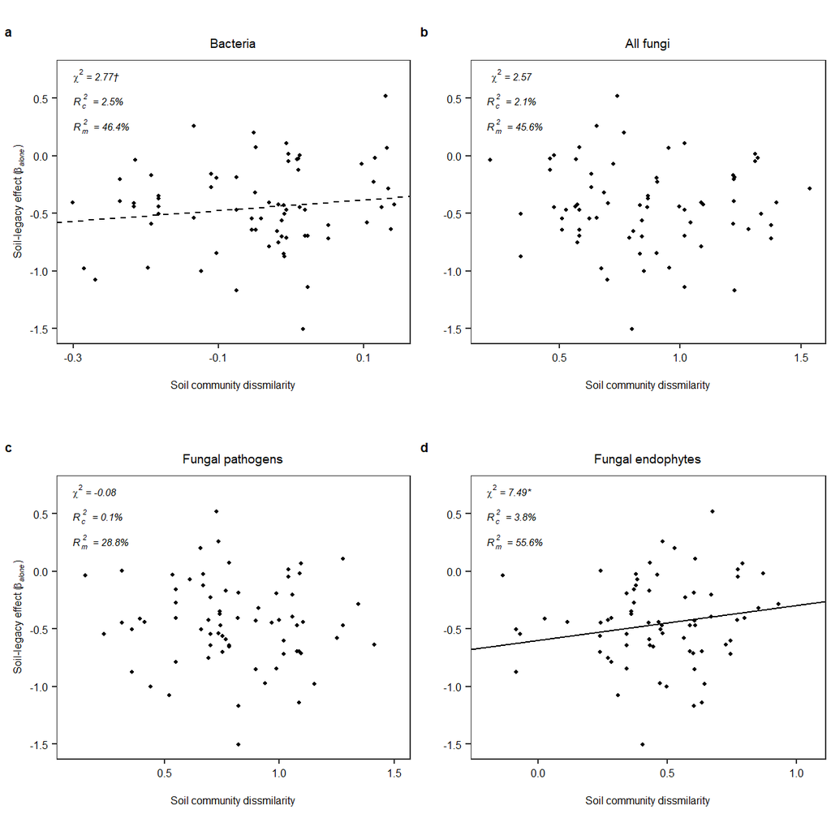

```r
grid.arrange(p1, p2, p3, p4, ncol = 2, nrow = 2)
```

Extended Fig. 5e & f

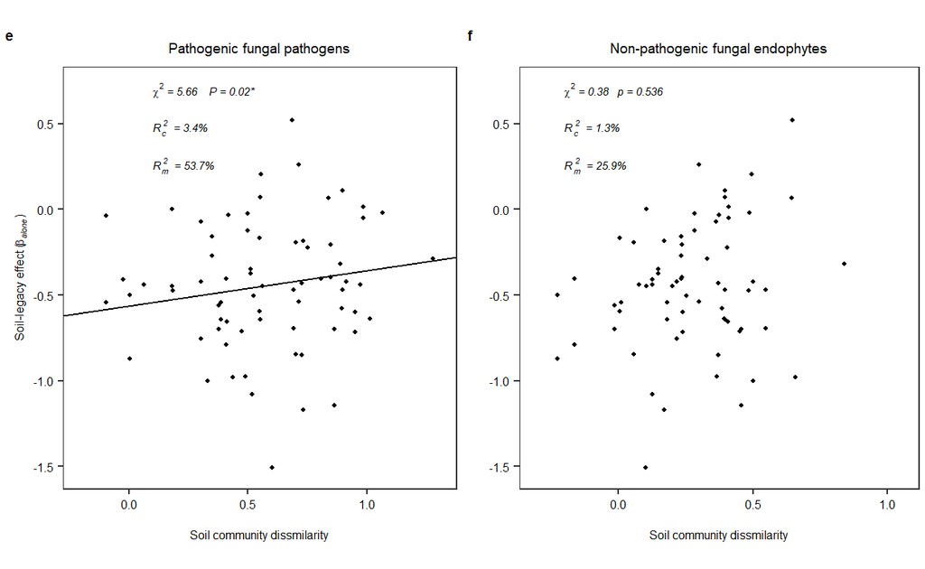

```r
grid.arrange(p5, p6, ncol = 2)
```

```r
# ggsave('./fig/legacy-beta.pdf',grid.arrange(p1, p2, p3, p4,
#                                          ncol = 2, nrow = 2), width = 12.5/2.54, height = 13/2.54,  useDingbats=FALSE)
```

```r
rm(model, model2, model3, model4, model5, model6)
```

### 6.1.2 beta_intra/beta_inter (Supplementary Fig. 5)

```r
dat_legacy_stren_na <- dat_legacy_stren %>%
  filter(!is.na(beta_16s_p1_target), !is.na(beta_16s_p1_target), !is.na(beta_16s_p2))
```

```r
u<-gl(1,1,length(dat_legacy_stren_na$biomass))

print('PSF ~ similarity in bacteria')
```

```
## [1] "PSF ~ similarity in bacteria"
```

```r
model1 <- lme(legacy_stren ~ logit(beta_16s_p1_target) + logit(beta_16s_p1_comp) + logit(beta_16s_p2) + intra_inter,
              random=list(u = pdBlocked(list(pdIdent(form=~family_p1-1), pdIdent(form=~sp_p1-1),
                                             pdIdent(form=~family-1), pdIdent(form=~sp_p2-1),
                                             pdIdent(form=~family_comp-1), pdIdent(form=~sp_p2_comp-1)))),
              data=dat_legacy_stren_na,
              weights = varComb(varIdent(form = ~ 1|sp_p2),
                                varIdent(form = ~ 1|sp_p1),
                                varIdent(form = ~ 1|sp_p2_comp)
              ),
              control = lmeControl(msMaxIter = 1000),
              method = "ML")

model2 <- update(model1, .~ logit(beta_its_p1_target)      + logit(beta_its_p1_comp)      + logit(beta_its_p2) + intra_inter)
model3 <- update(model1, .~ logit(beta_its_path_p1_target) + logit(beta_its_path_p1_comp) + logit(beta_its_path_p2) + intra_inter)
model4 <- update(model1, .~ logit(beta_its_endo_p1_target) + logit(beta_its_endo_p1_comp) + logit(beta_its_endo_p2) + intra_inter,
                 weights = varComb(varIdent(form = ~ 1|sp_p2),
                                   varIdent(form = ~ 1|sp_p2_comp)
                 ))
drop1(model1, test = 'Chisq' )[-1,] %>% lrt.table()
```

|  | Df | AIC | LRT | Pr(>Chi) |  |
| --- | --- | --- | --- | --- | --- |
| logit(beta_16s_p1_target) | 1 | 361.473 | 3.104 | 0.078 | † |
| logit(beta_16s_p1_comp) | 1 | 360.549 | 2.180 | 0.140 |  |
| logit(beta_16s_p2) | 1 | 360.463 | 2.094 | 0.148 |  |
| intra_inter | 1 | 358.416 | 0.047 | 0.829 |  |

```r
drop1(model2, test = 'Chisq' )[-1,] %>% lrt.table()
```

|  | Df | AIC | LRT | Pr(>Chi) |  |
| --- | --- | --- | --- | --- | --- |
| logit(beta_its_p1_target) | 1 | 348.723 | 0.262 | 0.609 |  |
| logit(beta_its_p1_comp) | 1 | 351.413 | 2.953 | 0.086 | † |
| logit(beta_its_p2) | 1 | 363.956 | 15.495 | 0.000 | * |
| intra_inter | 1 | 349.038 | 0.578 | 0.447 |  |

```r
drop1(model3, test = 'Chisq' )[-1,] %>% lrt.table()
```

|  | Df | AIC | LRT | Pr(>Chi) |  |
| --- | --- | --- | --- | --- | --- |
| logit(beta_its_path_p1_target) | 1 | 358.449 | 3.896 | 0.048 | * |
| logit(beta_its_path_p1_comp) | 1 | 361.016 | 6.462 | 0.011 | * |
| logit(beta_its_path_p2) | 1 | 359.987 | 5.434 | 0.020 | * |
| intra_inter | 1 | 354.605 | 0.052 | 0.820 |  |

```r
drop1(model4, test = 'Chisq' )[-1,] %>% lrt.table()
```

|  | Df | AIC | LRT | Pr(>Chi) |  |
| --- | --- | --- | --- | --- | --- |
| logit(beta_its_endo_p1_target) | 1 | 397.072 | 1.301 | 0.254 |  |
| logit(beta_its_endo_p1_comp) | 1 | 396.324 | 0.554 | 0.457 |  |
| logit(beta_its_endo_p2) | 1 | 395.837 | 0.066 | 0.797 |  |
| intra_inter | 1 | 395.790 | 0.020 | 0.888 |  |

```r
t_dis_16s_stren       <- merge_fix_rand(drop1(model1, test = 'Chisq')[-1,], model1)
t_dis_its_stren       <- merge_fix_rand(drop1(model2, test = 'Chisq')[-1,], model2)
t_dis_its_patho_stren <- merge_fix_rand(drop1(model3, test = 'Chisq')[-1,], model3)
t_dis_16s_endo_stren  <- merge_fix_rand(drop1(model4, test = 'Chisq')[-1,], model4)
# write.csv(rbind(t_dis_16s_stren,t_dis_its_stren, t_dis_its_patho_stren, t_dis_16s_endo_stren),
#           './table/psf_dis_stren.csv')
```

figure

```r
model2 <- update(model2, .~  logit(beta_its_p2), method = 'REML')
model3 <- update(model3, .~ logit(beta_its_path_p1_target), method = 'REML')
model4 <- update(model3, .~ logit(beta_its_path_p1_comp),   method = 'REML')
model5 <- update(model3, .~ logit(beta_its_path_p2),        method = 'REML')
```

```r
ylab = expression(paste('Soil legacy effect (', italic(beta['inter_intra']), ')','\n', sep = ''))

p1 <- dat_legacy_stren_na %>%
  ggplot() + aes(x = logit(beta_its_p2), y = legacy_stren) + geom_point(size = 0.8) +
  labs(x = 'Soil community dissmilarity between test species', y = ylab, title = 'All fungi', tag = 'a') +
  theme +
  geom_abline(intercept = summary(model2)$coef$fixed[1], slope = summary(model2)$coef$fixed[2]) +
  scale_x_continuous(breaks=pretty_breaks(n = 3))


p2 <- dat_legacy_stren_na %>%
  ggplot() + aes(x = logit(beta_its_path_p1_target), y = legacy_stren) + geom_point(size = 0.8) +
  labs(x = 'Soil community dissmilarity between soil and focal test species', y = ' ', title = 'Fungal pathogens', tag = 'b') +
  theme +
  geom_abline(intercept = summary(model3)$coef$fixed[1], slope = summary(model3)$coef$fixed[2]) +
  scale_x_continuous(breaks=pretty_breaks(n = 3))

p3 <- dat_legacy_stren_na %>%
  ggplot() + aes(x = logit(beta_its_path_p1_comp), y = legacy_stren) + geom_point(size = 0.8) +
  labs(x = 'Soil community dissmilarity between soil and competitor test species', y = ylab, title = 'Fungal pathogens', tag = 'c') +
  theme +
  geom_abline(intercept = summary(model4)$coef$fixed[1], slope = summary(model4)$coef$fixed[2]) +
  scale_x_continuous(breaks=pretty_breaks(n = 3))

p4 <- dat_legacy_stren_na %>%
  ggplot() + aes(x = logit(beta_its_path_p2), y = legacy_stren) + geom_point(size = 0.8) +
  labs(x = 'Soil community dissmilarity between test species', y = ' ', title = 'Fungal pathogens', tag = 'd') +
  theme +
  geom_abline(intercept = summary(model5)$coef$fixed[1], slope = summary(model5)$coef$fixed[2]) +
  scale_x_continuous(breaks=pretty_breaks(n = 3))
```

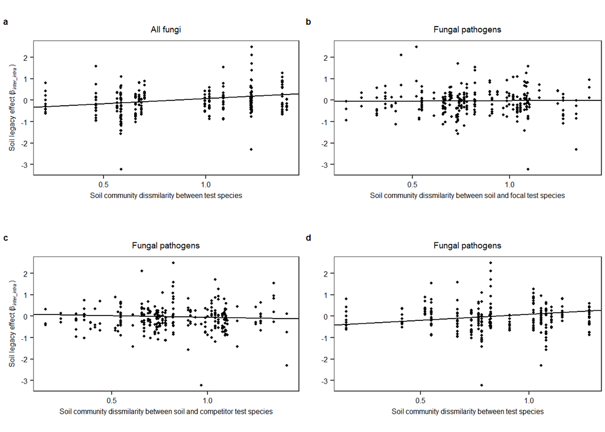

```r
grid.arrange(p1, p2, p3, p4,ncol = 2)
```

```r
# ggsave('./fig/legacy~dis_stren.pdf', grid.arrange(p1, p2, p3, p4,ncol = 2), height = 7, width = 7.5)
```

## 6.2 enemy release

### 6.2.1 beta_alone (Extended Fig. 4)

legacy ~ abundance of fungal pathogens

```r
u<-gl(1,1,length(dat_legacy_alone$biomass))
model<-lme(legacy_alone ~ logit(abun_path) * origin_p2,
           random=list(u=pdBlocked(list(
            pdIdent(form=~family_p1-1),
            pdIdent(form=~sp_p1-1),
            pdIdent(form=~family-1),
            pdIdent(form=~sp_p2-1)
            ))),
          data=dat_legacy_alone,
          weights = varComb(varIdent(form = ~1|sp_p2),
                            varIdent(form = ~ 1|sp_p1)),
          control = lmeControl(msMaxIter = 1000),
          method = "ML")
r1 <- drop1(model, test ='Chisq')[-1,]
r2 <- drop1(update(model,.~.- logit(abun_path) : origin_p2), test ='Chisq')[-1,]

t_legacy_ab_path <- merge_fix_rand(rbind(r2,r1), model)
t_legacy_ab_path %>% kable
```

|  | X2 | P |
| --- | --- | --- |
| logit(abun_path) | 2.005 | 0.157 |
| origin_p2 | 2.613 | 0.106 |
| logit(abun_path):origin_p2 | 1.745 | 0.187 |
| Random effects | SD |  |
| family_p1 | 0.123 |  |
| sp_p1 | 0.128 |  |
| family | 0.095 |  |
| sp_p2 | 0.000 |  |
| Residual | 0.186 |  |

legacy ~ diversity 16s_species_richness

```r
model<-lme(legacy_alone ~ div_16s_sr * origin_p2,
           random=list(u=pdBlocked(list(
            pdIdent(form=~family_p1-1),
            pdIdent(form=~sp_p1-1),
            pdIdent(form=~family-1),
            pdIdent(form=~sp_p2-1)
            ))),
          data=dat_legacy_alone,
          weights = varComb(varIdent(form = ~1|sp_p2),
                            varIdent(form = ~ 1|sp_p1)),
          control = lmeControl(msMaxIter = 1000),
          method = "ML")
r1 <- drop1(model, test ='Chisq')[-1,]
r2 <- drop1(update(model,.~.- div_16s_sr : origin_p2), test ='Chisq')[-1,]
t_legacy_sr_16s <- merge_fix_rand(rbind(r2,r1), model)
t_legacy_sr_16s %>% kable
```

|  | X2 | P |
| --- | --- | --- |
| div_16s_sr | 0.594 | 0.441 |
| origin_p2 | 2.555 | 0.110 |
| div_16s_sr:origin_p2 | 0.509 | 0.475 |
| Random effects | SD |  |
| family_p1 | 0.156 |  |
| sp_p1 | 0.110 |  |
| family | 0.092 |  |
| sp_p2 | 0.000 |  |
| Residual | 0.185 |  |

16s_shannon

```r
model<- update(model, .~ div_16s_shan * origin_p2)
r1 <- drop1(model, test ='Chisq')[-1,]
r2 <- drop1(update(model,.~.- div_16s_shan : origin_p2), test ='Chisq')[-1,]
t_legacy_shan_16s <- merge_fix_rand(rbind(r2,r1), model)
t_legacy_shan_16s %>% kable
```

|  | X2 | P |
| --- | --- | --- |
| div_16s_shan | 0.384 | 0.535 |
| origin_p2 | 2.576 | 0.108 |
| div_16s_shan:origin_p2 | 0.845 | 0.358 |
| Random effects | SD |  |
| family_p1 | 0.113 |  |
| sp_p1 | 0.135 |  |
| family | 0.097 |  |
| sp_p2 | 0.000 |  |
| Residual | 0.231 |  |

its_species_richness

```r
model<- update(model, .~ div_its_sr * origin_p2)
r1 <- drop1(model, test ='Chisq')[-1,]
r2 <- drop1(update(model,.~.- div_its_sr : origin_p2), test ='Chisq')[-1,]
t_legacy_sr_its <- merge_fix_rand(rbind(r2,r1), model)
t_legacy_sr_its %>% kable
```

|  | X2 | P |
| --- | --- | --- |
| div_its_sr | 3.856 | 0.050† |
| origin_p2 | 2.579 | 0.108 |
| div_its_sr:origin_p2 | 0.501 | 0.479 |
| Random effects | SD |  |
| family_p1 | 0.175 |  |
| sp_p1 | 0.077 |  |
| family | 0.097 |  |
| sp_p2 | 0.000 |  |
| Residual | 0.201 |  |

its_shannon_diversity

```r
model<- update(model, .~ div_its_shan * origin_p2)
r1 <- drop1(model, test ='Chisq')[-1,]
r2 <- drop1(update(model,.~.- div_its_shan : origin_p2), test ='Chisq')[-1,]
t_legacy_shan_its <- merge_fix_rand(rbind(r2,r1), model)
t_legacy_shan_its %>% kable
```

|  | X2 | P |
| --- | --- | --- |
| div_its_shan | 1.656 | 0.198 |
| origin_p2 | 2.761 | 0.097† |
| div_its_shan:origin_p2 | 0.080 | 0.777 |
| Random effects | SD |  |
| family_p1 | 0.201 |  |
| sp_p1 | 0.060 |  |
| family | 0.097 |  |
| sp_p2 | 0.000 |  |
| Residual | 0.199 |  |

pathogen_species_richness

```r
model1<- update(model, .~ div_path_sr * origin_p2)
r1 <- drop1(model1, test ='Chisq')[-1,]
r2 <- drop1(update(model1,.~.- div_path_sr : origin_p2), test ='Chisq')[-1,]
rbind(r2,r1) %>% lrt.table()
```

|  | Df | AIC | LRT | Pr(>Chi) |  |
| --- | --- | --- | --- | --- | --- |
| div_path_sr | 1 | 68.389 | 2.430 | 0.119 |  |
| origin_p2 | 1 | 68.604 | 2.645 | 0.104 |  |
| div_path_sr:origin_p2 | 1 | 67.959 | 0.756 | 0.385 |  |

```r
t_legacy_sr_path <- merge_fix_rand(rbind(r2,r1), model1)
```

pathogen_shannon_diversity

```r
model2 <- update(model, .~ div_path_shan * origin_p2)
r1 <- drop1(model2, test ='Chisq')[-1,]
r2 <- drop1(update(model2,.~.- div_path_shan : origin_p2), test ='Chisq')[-1,]
rbind(r2,r1) %>% lrt.table()
```

|  | Df | AIC | LRT | Pr(>Chi) |  |
| --- | --- | --- | --- | --- | --- |
| div_path_shan | 1 | 68.389 | 1.269 | 0.260 |  |
| origin_p2 | 1 | 69.621 | 2.501 | 0.114 |  |
| div_path_shan:origin_p2 | 1 | 69.121 | 0.345 | 0.557 |  |

```r
t_legacy_shan_path <- merge_fix_rand(rbind(r2,r1), model2)
```

export table

```r
# write.csv(cbind(t_legacy_ab_path,
#                 t_legacy_sr_16s,   t_legacy_sr_its,   t_legacy_sr_path,
#                 t_legacy_shan_16s, t_legacy_shan_its, t_legacy_shan_path),
#           './table/legacy_ab_div.csv')
```

```r
theme <- theme +
  theme(plot.margin = margin(t = 0.5, r = 0.3, b = 0.5, l = 0.1, unit = "cm"))
ylab = expression(paste('Soil legacy effect (', italic(beta['alone']), ')','\n', sep = ''))
p1 <- dat_legacy_alone %>%
  ggplot() + aes(x = div_16s_sr, y = legacy_alone, col = origin_p2) +
  geom_point(size = 0.8) + labs(x = '\nSpecies richness', y = ylab,
                                title = 'Bacteria', tag = 'a') +
  theme + scale_x_continuous(limits = c(3000, 4000),
                             breaks=pretty_breaks(n = 3)) +
  scale_color_manual(values = t_col(col_fig)) +
  # legend
  theme(legend.position = c(0.72,0.2),
        legend.text = element_text(size = 7),
        legend.key.height = unit(0.6,'line'))

p2 <- dat_legacy_alone %>%
  ggplot() + aes(x = div_its_sr, y = legacy_alone, col = origin_p2) +
  geom_point(size = 0.8) + labs(x = '\nSpecies richness', y = ' ',
                                title = 'All fungi', tag = 'b') +
  theme + scale_x_continuous(breaks=pretty_breaks(n = 3)) +
  scale_color_manual(values = t_col(col_fig))

p3 <- dat_legacy_alone %>%
  ggplot() + aes(x = div_16s_shan, y = legacy_alone, col = origin_p2) +
  geom_point(size = 0.8) + labs(x = '\nShannon diversity', y = ylab,
                                title = ' ', tag = 'd') +
  theme + scale_x_continuous(limits = c(6.6, 7.2), breaks=pretty_breaks(n = 3)) +
  scale_color_manual(values = t_col(col_fig))
p4 <- dat_legacy_alone %>%
  ggplot() + aes(x = div_its_shan, y = legacy_alone, col = origin_p2) +
  geom_point(size = 0.8) + labs(x = '\nShannon diversity', y = ' ',
                                title = ' ', tag = 'e') +
  theme + scale_x_continuous(breaks=pretty_breaks(n = 3)) +
  scale_color_manual(values = t_col(col_fig))
```

```r
p5 <- dat_legacy_alone %>%
  ggplot() + aes(x = logit(abun_path), y = legacy_alone, col = origin_p2) +
  geom_point(size = 0.8) + labs(x = 'Relative abundance', y = ylab,
                                title = ' ', tag = 'g') +
  theme + scale_x_continuous(# limits = c(0.425, 0.55),
                             breaks=pretty_breaks(n = 3)) +
  scale_color_manual(values = t_col(col_fig))

# diversity
p6 <- dat_legacy_alone %>%
  ggplot() + aes(x = div_path_sr, y = legacy_alone, col = origin_p2) +
  geom_point(size = 0.8) + labs(x = 'Species richness', y = ' ', title = 'Fungal pathogens', tag = 'c') +
  theme + scale_x_continuous(# limits = c(0.425, 0.55),
                             breaks=pretty_breaks(n = 3)) +
  scale_color_manual(values = t_col(col_fig))



p7 <- dat_legacy_alone %>%
  ggplot() + aes(x = div_path_shan, y = legacy_alone, col = origin_p2) +
  geom_point(size = 0.8) + labs(x = 'Shannon diversity', y = ' ', title = ' ', tag = 'f') +
  theme + scale_x_continuous(# limits = c(0.425, 0.55),
                             breaks=pretty_breaks(n = 4)) +
  scale_color_manual(values = t_col(col_fig))
```

```r
# ggsave('./fig/legacy~div.pdf', height = 6, width = 14/2.54,
#        grid.arrange(p1,   p2,   p6,
#                     p3, p4, p7,
#                     p5,
#                     layout_matrix = matrix(c(1:6, NA, NA, 7), nrow =3, ncol = 3, byrow = T)))
```

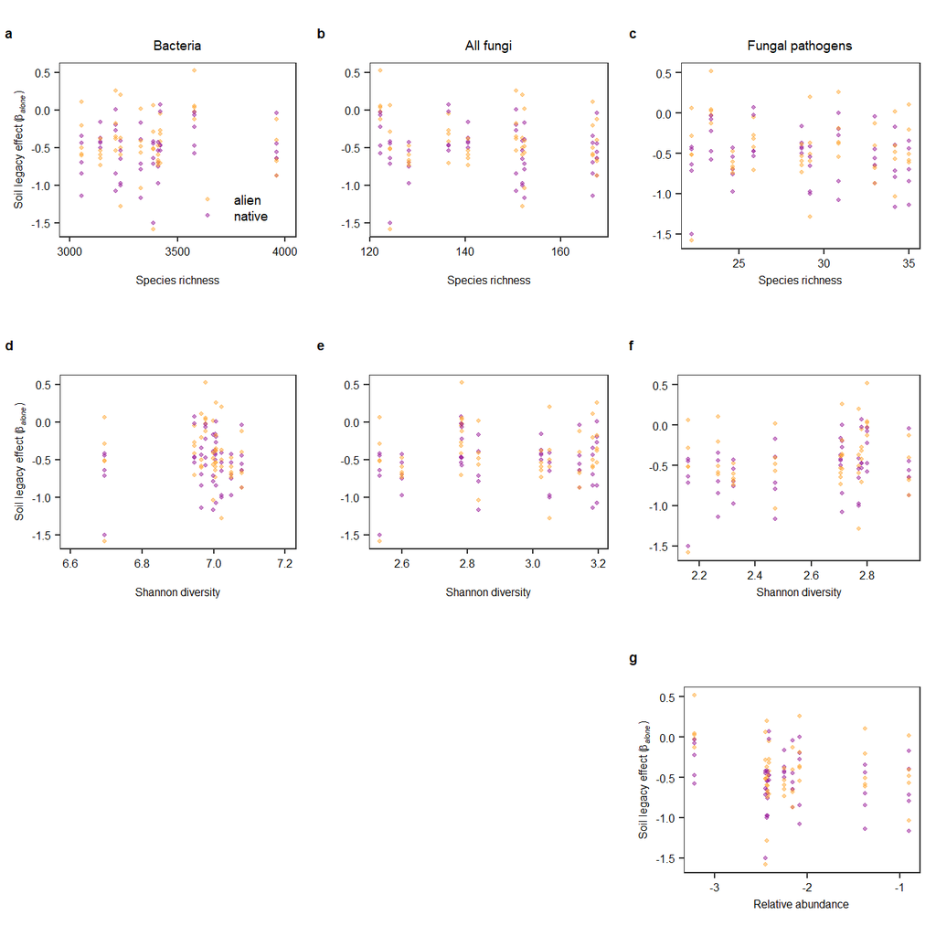

```r
grid.arrange(p1, p2, p6,
             p3, p4, p7,
             p5,
             layout_matrix = matrix(c(1:6, NA, NA, 7), nrow =3, ncol = 3, byrow = T))
```

### 6.2.2 beta_inter/beta_intra (Supplementary Fig.4)

strength of competition

```r
u<-gl(1,1,length(dat_legacy_stren$legacy_stren))
```

16s species richness

```r
model <- lme(legacy_stren ~ intra_inter + div_16s_sr * origin_p2 ,
           random=list(u=pdBlocked(list(pdIdent(form=~family_p1-1), pdIdent(form=~sp_p1-1),
                                        pdIdent(form=~family-1),    pdIdent(form=~sp_p2-1),
                                        pdIdent(form=~family_comp-1),pdIdent(form=~sp_p2_comp-1)))),
            data=dat_legacy_stren,
            weights = varComb(varIdent(form = ~ 1|sp_p2),
                              varIdent(form = ~ 1|sp_p1),
                              varIdent(form = ~ 1|sp_p2_comp)),
            control = lmeControl(msMaxIter = 1000),
            method = "ML")
```

```r
r1 <- drop1(model, test ='Chisq')[-c(1:2),]
r2 <- drop1(update(model,.~.- div_16s_sr : origin_p2), test ='Chisq')[-1,]
t_legacy_sr_16s_stren <- merge_fix_rand(rbind(r2,r1), model)
t_legacy_sr_16s_stren %>% kable
```

|  | X2 | P |
| --- | --- | --- |
| intra_inter | 0.004 | 0.950 |
| div_16s_sr | 0.006 | 0.940 |
| origin_p2 | 0.681 | 0.409 |
| div_16s_sr:origin_p2 | 0.776 | 0.378 |
| Random effects | SD |  |
| family_p1 | 0.031 |  |
| sp_p1 | 0.075 |  |
| family | 0.000 |  |
| sp_p2 | 0.228 |  |
| family_comp | 0.138 |  |
| sp_p2_comp | 0.000 |  |
| Residual | 0.648 |  |

16s shannon diversity

```r
model2 <- update(model, .~ intra_inter + div_16s_shan * origin_p2 )
r1 <- drop1(model2, test ='Chisq')[-c(1:2),]
r2 <- drop1(update(model2,.~.- div_16s_shan : origin_p2), test ='Chisq')[-1,]
t_legacy_sh_16s_stren <- merge_fix_rand(rbind(r2,r1), model2)
t_legacy_sh_16s_stren %>% kable
```

|  | X2 | P |
| --- | --- | --- |
| intra_inter | 0.004 | 0.952 |
| div_16s_shan | 0.091 | 0.763 |
| origin_p2 | 0.682 | 0.409 |
| div_16s_shan:origin_p2 | 4.500 | 0.034* |
| Random effects | SD |  |
| family_p1 | 0.025 |  |
| sp_p1 | 0.074 |  |
| family | 0.000 |  |
| sp_p2 | 0.227 |  |
| family_comp | 0.137 |  |
| sp_p2_comp | 0.000 |  |
| Residual | 0.658 |  |

its species richness

```r
model3 <- update(model, .~ intra_inter + div_its_sr * origin_p2 )
r1 <- drop1(model3, test ='Chisq')[-c(1:2),]
r2 <- drop1(update(model3,.~.- div_its_sr : origin_p2), test ='Chisq')[-1,]
t_legacy_sr_its_stren <- merge_fix_rand(rbind(r2,r1), model3)
t_legacy_sr_its_stren %>% kable
```

|  | X2 | P |
| --- | --- | --- |
| intra_inter | 0.002 | 0.962 |
| div_its_sr | 1.301 | 0.254 |
| origin_p2 | 0.691 | 0.406 |
| div_its_sr:origin_p2 | 1.406 | 0.236 |
| Random effects | SD |  |
| family_p1 | 0.056 |  |
| sp_p1 | 0.059 |  |
| family | 0.000 |  |
| sp_p2 | 0.225 |  |
| family_comp | 0.137 |  |
| sp_p2_comp | 0.000 |  |
| Residual | 0.631 |  |

its shannon diversity

```r
model4 <- update(model, .~ intra_inter + div_its_shan * origin_p2 )
r1 <- drop1(model4, test ='Chisq')[-c(1:2),]
r2 <- drop1(update(model4,.~.- div_its_shan : origin_p2), test ='Chisq')[-1,]
t_legacy_sh_its_stren <- merge_fix_rand(rbind(r2,r1), model4)
t_legacy_sh_its_stren %>% kable
```

|  | X2 | P |
| --- | --- | --- |
| intra_inter | 0.004 | 0.949 |
| div_its_shan | 0.009 | 0.926 |
| origin_p2 | 0.681 | 0.409 |
| div_its_shan:origin_p2 | 0.958 | 0.328 |
| Random effects | SD |  |
| family_p1 | 0.026 |  |
| sp_p1 | 0.077 |  |
| family | 0.000 |  |
| sp_p2 | 0.226 |  |
| family_comp | 0.137 |  |
| sp_p2_comp | 0.000 |  |
| Residual | 0.632 |  |

fungal pathogens

```r
print('abundance')
```

```
## [1] "abundance"
```

```r
model5 <- update(model, .~ intra_inter + abun_path * origin_p2 )
r1 <- drop1(model5, test ='Chisq')[-c(1:2),]
r2 <- drop1(update(model5,.~.- abun_path : origin_p2), test ='Chisq')[-1,]
t_legacy_ab_path_stren <- merge_fix_rand(rbind(r2,r1), model4)
t_legacy_ab_path_stren %>% kable
```

|  | X2 | P |
| --- | --- | --- |
| intra_inter | 0.004 | 0.950 |
| abun_path | 0.173 | 0.677 |
| origin_p2 | 0.683 | 0.409 |
| abun_path:origin_p2 | 0.427 | 0.514 |
| Random effects | SD |  |
| family_p1 | 0.026 |  |
| sp_p1 | 0.077 |  |
| family | 0.000 |  |
| sp_p2 | 0.226 |  |
| family_comp | 0.137 |  |
| sp_p2_comp | 0.000 |  |
| Residual | 0.632 |  |

```r
print('species richness')
```

```
## [1] "species richness"
```

```r
model6 <- update(model, .~ intra_inter + div_path_sr * origin_p2 )
r1 <- drop1(model6, test ='Chisq')[-c(1:2),]
r2 <- drop1(update(model6,.~.- div_path_sr : origin_p2), test ='Chisq')[-1,]
t_legacy_sr_path_stren <- merge_fix_rand(rbind(r2,r1), model4)
t_legacy_sr_path_stren %>% kable
```

|  | X2 | P |
| --- | --- | --- |
| intra_inter | 0.003 | 0.955 |
| div_path_sr | 0.410 | 0.522 |
| origin_p2 | 0.686 | 0.408 |
| div_path_sr:origin_p2 | 1.800 | 0.180 |
| Random effects | SD |  |
| family_p1 | 0.026 |  |
| sp_p1 | 0.077 |  |
| family | 0.000 |  |
| sp_p2 | 0.226 |  |
| family_comp | 0.137 |  |
| sp_p2_comp | 0.000 |  |
| Residual | 0.632 |  |

```r
print('shannon diversity')
```

```
## [1] "shannon diversity"
```

```r
model7 <- update(model, .~ intra_inter + div_path_shan * origin_p2 )
r1 <- drop1(model7, test ='Chisq')[-c(1:2),]
r2 <- drop1(update(model7,.~.- div_path_shan : origin_p2), test ='Chisq')[-1,]
t_legacy_sh_path_stren <- merge_fix_rand(rbind(r2,r1), model4)
t_legacy_sh_path_stren %>% kable
```

|  | X2 | P |
| --- | --- | --- |
| intra_inter | 0.005 | 0.941 |
| div_path_shan | 0.397 | 0.529 |
| origin_p2 | 0.681 | 0.409 |
| div_path_shan:origin_p2 | 7.108 | 0.008* |
| Random effects | SD |  |
| family_p1 | 0.026 |  |
| sp_p1 | 0.077 |  |
| family | 0.000 |  |
| sp_p2 | 0.226 |  |
| family_comp | 0.137 |  |
| sp_p2_comp | 0.000 |  |
| Residual | 0.632 |  |

```r
# write.csv(rbind(t_legacy_sr_16s_stren, t_legacy_sh_16s_stren, t_legacy_sr_its_stren, t_legacy_sh_its_stren), './table/legacy_div_stren.csv')
# write.csv(rbind(t_legacy_ab_path_stren, t_legacy_sr_path_stren, t_legacy_sh_path_stren), './table/legacy_ab_div_stren.csv')
```

```r
model2 <-update(model2, .~. - intra_inter, method = 'REML')
```

```r
# figure bacteria and fungi
ylab = expression(paste('Soil legacy effect (', italic(beta['inter_intra']), ')','\n', sep = ''))
p1 <- dat_legacy_stren %>%
  ggplot() + aes(x = div_16s_sr, y = legacy_stren, col = origin_p2) +
  geom_point(size = 0.8) + labs(x = '\nSpecies richness', y = ylab,
                                title = 'Bacteria', tag = 'a') +
  theme +
  scale_color_manual(values = t_col(col_fig)) +
  theme(legend.position = c(0.8,0.2),
        legend.text = element_text(size = 7),
        legend.key.height = unit(0.8,'line'))

p2 <- dat_legacy_stren %>%
  ggplot() + aes(x = div_its_sr, y = legacy_stren, col = origin_p2) +
  geom_point(size = 0.8) + labs(x = '\nSpecies richness', y = ' ',
                                title = 'All fungi', tag = 'b') +
  theme +
  scale_color_manual(values = t_col(col_fig))


p3 <- dat_legacy_stren %>%
  ggplot() + aes(x = div_16s_shan, y = legacy_stren, col = origin_p2) +
  geom_point(size = 0.8) + labs(x = '\nShannon diversity', y = ylab,
                                title = ' ', tag = 'd') +
  theme + scale_x_continuous(breaks=pretty_breaks(n = 4)) +
  scale_color_manual(values = t_col(col_fig)) +
  geom_abline(intercept = summary(model2)$coef$fixed[1],
              slope = summary(model2)$coef$fixed[2], col = col_fig[1]) +
  geom_abline(intercept = summary(model2)$coef$fixed[c(1,3)] %>% sum ,
              slope = summary(model2)$coef$fixed[c(2,4)] %>% sum, col = col_fig[2])

p4 <- dat_legacy_stren %>%
  ggplot() + aes(x = div_its_shan, y = legacy_stren, col = origin_p2) +
  geom_point(size = 0.8) + labs(x = '\nShannon diversity', y = ' ',
                                title = ' ', tag = 'e') +
  theme + scale_x_continuous(breaks=pretty_breaks(n = 4)) +
  scale_color_manual(values = t_col(col_fig))
```

```r
model7 <-update(model7, .~. - intra_inter, method = 'REML')
```

```r
# figure fungal pathogens
p5 <- dat_legacy_stren %>%
  ggplot() + aes(x = abun_path, y = legacy_stren, col = origin_p2) +
  geom_point(size = 0.8) + labs(x = '\nRelative abundance', y = ylab,
                                title = ' ', tag = 'g') +
  theme + scale_x_continuous(breaks=pretty_breaks(n = 4)) +
  scale_color_manual(values = t_col(col_fig))

p6 <- dat_legacy_stren %>%
  ggplot() + aes(x = div_path_sr, y = legacy_stren, col = origin_p2) +
  geom_point(size = 0.8) + labs(x = '\nSpecies richness', y = ' ',
                                title = 'Fungal pathogens', tag = 'c') +
  theme + scale_x_continuous(breaks=pretty_breaks(n = 3)) +
  scale_color_manual(values = t_col(col_fig))



p7 <- dat_legacy_stren %>%
  ggplot() + aes(x = div_path_shan, y = legacy_stren, col = origin_p2) +
  geom_point(size = 0.8) + labs(x = '\nShannon diversity', y = ' ',
                                title = ' ', tag = 'f') +
  theme + scale_x_continuous(breaks=pretty_breaks(n = 4)) +
  scale_color_manual(values = t_col(col_fig)) +
  geom_abline(intercept = summary(model7)$coef$fixed[1], slope = summary(model7)$coef$fixed[2], col = col_fig[1]) +
  geom_abline(intercept = summary(model7)$coef$fixed[c(1,3)] %>% sum , slope = summary(model7)$coef$fixed[c(2,4)] %>% sum, col = col_fig[2])
```

```r
ggsave('./fig/legacy_stren~div.pdf', height = 7, width = 18/2.54,
        grid.arrange(p1, p2, p6,
                     p3, p4, p7,
                     p5, layout_matrix = matrix(c(1:6, NA, NA, 7), nrow =3, ncol = 3, byrow = T)))
```

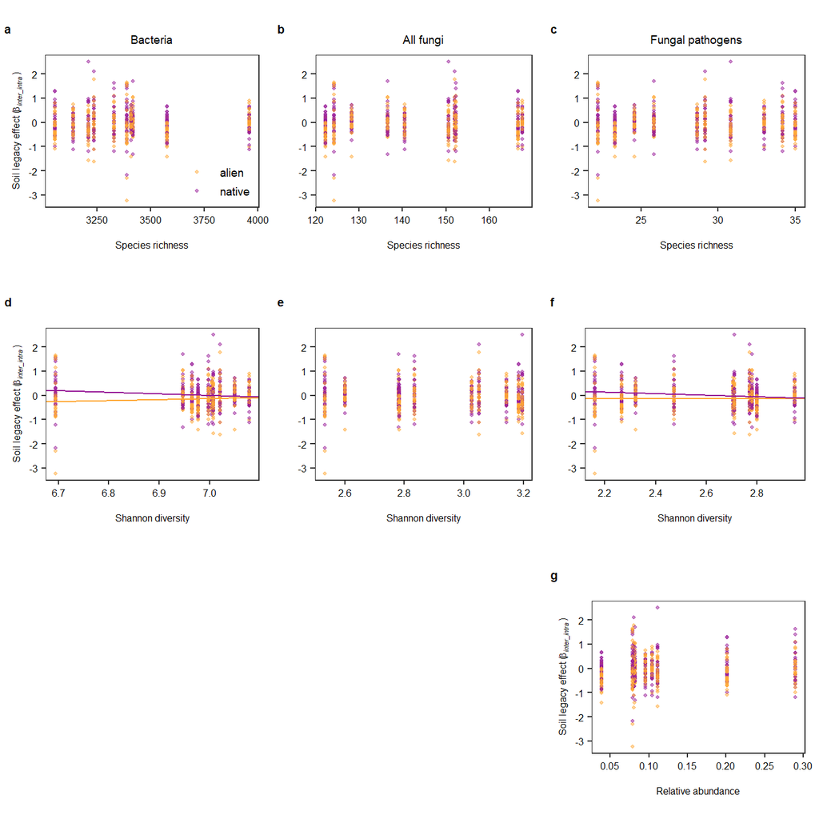

```r
grid.arrange(p1, p2, p6,
             p3, p4, p7,
             p5, layout_matrix = matrix(c(1:6, NA, NA, 7), nrow =3, ncol = 3, byrow = T))
```

# 7 taxa

most abundant phyla in bacteria and fungi. (Supplementary Figure 2)

```r
reads_no <- sum(otu_table_16s[1,])
otu_table_16s_tax <- (otu_table_16s/reads_no) %>%
  rownames_to_column('sample_id') %>%
  gather('gene', 'abundance', -sample_id) %>%
  left_join(tax_table_16s %>% rownames_to_column('gene')) %>% #join tax
  left_join(sam_table_16s) %>%
  group_by(species,sample_id, Phylum, status, ster.not) %>%
  summarise(abundance = sum(abundance)) %>%
  group_by(species, Phylum, status, ster.not) %>%
  summarise(`Relative abundance` = mean(abundance)) %>%
  ungroup() %>%
  mutate(status = factor(status, levels = c( 'non-conditioned', 'alien', 'native'))) %>%
  arrange(ster.not, status, species)

otu_table_16s_tax$species <- factor(otu_table_16s_tax$species, levels = as.character(unique(otu_table_16s_tax$species))) # order by status
```

```r
reads_no <- sum(otu_table_its[1,])
otu_table_its_tax <- (otu_table_its/reads_no) %>%
  rownames_to_column('sample_id') %>%
  gather('gene', 'abundance', -sample_id) %>%
  left_join(tax_table_its %>% rownames_to_column('gene')) %>% #join tax
  left_join(sam_table_its) %>%
  group_by(species,sample_id, Phylum, species, status, ster.not) %>%
  summarise(abundance = sum(abundance)) %>%
  group_by(species, Phylum, species, status, ster.not) %>%
  summarise(`Relative abundance` = mean(abundance)) %>%
  ungroup() %>%
  mutate(status = factor(status, levels = c( 'non-conditioned', 'alien', 'native'))) %>%
  arrange(ster.not, status, species)

otu_table_its_tax$species <- factor(otu_table_its_tax$species, levels = as.character(unique(otu_table_its_tax$species)))
```

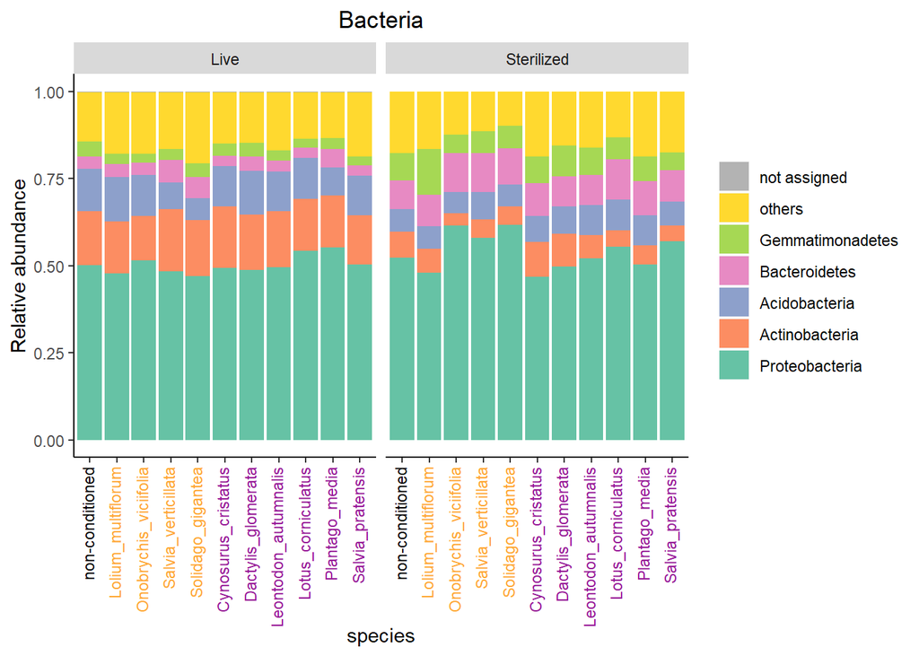

```r
# get top 5 abundant phyla
top <- (otu_table_16s_tax %>%
  group_by(Phylum) %>%
  summarise(mean = mean(`Relative abundance`)) %>%
  arrange(-mean) %>%
  top_n(5)) $ Phylum %>% as.character()
otu_table_16s_tax %>%
  mutate(phylum_clean = ifelse(is.na(Phylum), 'not assigned',
                                ifelse(Phylum%in% top, as.character(Phylum),'others'))) %>%
  mutate(phylum_clean = factor(phylum_clean, levels = c('not assigned', 'others', top[5:1]))) %>%
  ggplot() + aes( x = species, y = `Relative abundance`, fill = phylum_clean) + geom_bar(position="stack", stat="identity") +
  facet_wrap( ~ ster.not,labeller = labeller(ster.not = c('nonster' = 'Live', 'ster' = 'Sterilized'))) +
  theme(axis.text.x = element_text(angle = 90, hjust = 1, vjust = 0.3,
                                   color = c('black',rep(col_fig[1],4), rep(col_fig[2],6)))) +
  ggtitle('Bacteria') +
  scale_fill_manual(values = brewer.pal(8,'Set2')[c(8,6:1)]) + # filling colors
  theme(panel.grid.major = element_blank(), panel.grid.minor = element_blank(), # remove background
        panel.background = element_blank(), axis.line = element_line(colour = "black"),
        legend.title = element_blank(),
        plot.title = element_text(hjust = 0.5))
```

```r
# ggsave('./fig/sup_taxa_16s.pdf', plot = last_plot(), width = 6, height = 4)
```

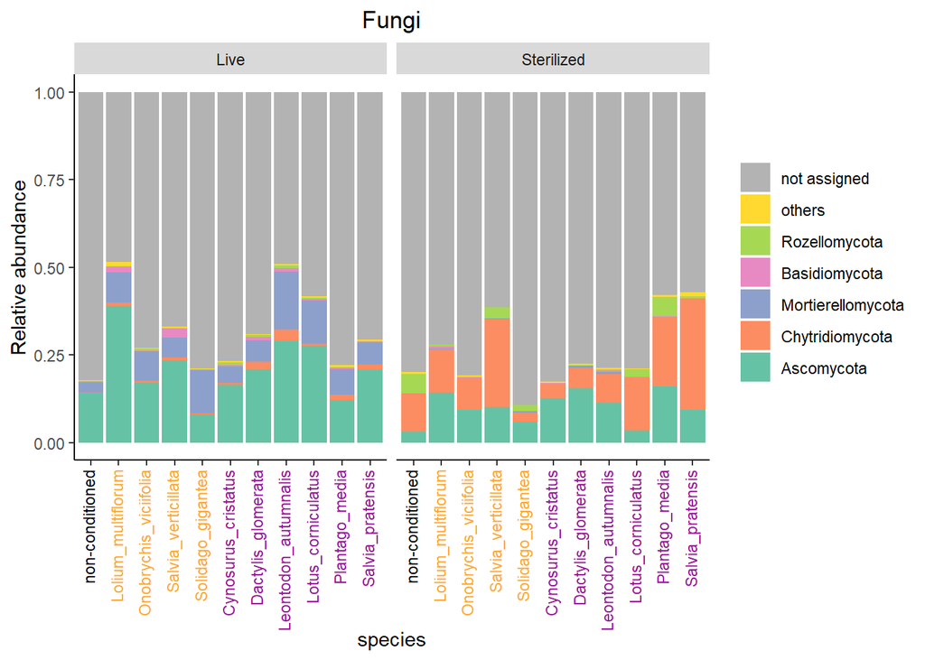

```r
# get top abundant phyla
top <- (otu_table_its_tax %>%
  group_by(Phylum) %>%
  summarise(mean = mean(`Relative abundance`)) %>%
  arrange(-mean) %>%
  top_n(6)) $ Phylum %>% as.character()

otu_table_its_tax %>%
  mutate(phylum_clean = ifelse(is.na(Phylum), 'not assigned',
                                ifelse(Phylum%in% top, as.character(Phylum),'others'))) %>%
  mutate(phylum_clean = sub('\\w__', '',phylum_clean)) %>% #remove 'w_'
  mutate(phylum_clean = factor(phylum_clean, levels = c('not assigned', 'others', 'Rozellomycota', 'Basidiomycota',
                                                        'Mortierellomycota', 'Chytridiomycota', 'Ascomycota'))) %>%
  ggplot() + aes( x = species, y = `Relative abundance`, fill = phylum_clean) + geom_bar(position="stack", stat="identity") +
  facet_wrap( ~ ster.not,labeller = labeller(ster.not = c('nonster' = 'Live', 'ster' = 'Sterilized'))) +
  theme(axis.text.x = element_text(angle = 90, hjust = 1, vjust = 0.3, color = c('black',rep(col_fig[1],4), rep(col_fig[2],6)))) +
  ggtitle('Fungi') +
  scale_fill_manual(values = brewer.pal(8,'Set2')[c(8,6:1)]) +
  theme(panel.grid.major = element_blank(), panel.grid.minor = element_blank(),
        panel.background = element_blank(), axis.line = element_line(colour = "black"),
        legend.title = element_blank(),
        plot.title = element_text(hjust = 0.5))
```

```r
# ggsave('./fig/sup_taxa_its.pdf', plot = last_plot(), width = 6, height = 4)
```